# Einführung in die angewandte Sozialstrukturanalyse

Teil I: Grundlagen

Autor:in

Carsten Sauer, Jule Adriaans

*Zitationshinweis: Sauer, Carsten & Adriaans, Jule (2025). “Einführung in die angewandte Sozialstrukturanalyse. Teil I: Grundlagen”. Unveröffentlichtes Manuskript, Universität Bielefeld.*

## 1 Einleitung — Was ist Sozialstrukturanalyse?

Menschen sind soziale Wesen. Von Geburt an sind wir in vielfältige soziale Kontexte eingebunden: Wir wachsen in Familien auf, besuchen Kindertagesstätten und Schulen, absolvieren eine Ausbildung oder ein Studium, gehen später einer Erwerbstätigkeit nach — sei es im Angestelltenverhältnis oder als Selbstständige — gründen möglicherweise unsere eigene Familie und treten schließlich in den Ruhestand. Überall in unserem Leben pflegen wir langfristige Beziehungen — sei es in Familien, Freundschaften oder in Vereinen — und haben kurzfristige soziale Kontakte, wie zum Beispiel beim Einkauf im Supermarkt oder beim kurzen Gespräch in der Bahn.

Neben den direkten Beziehungen zu unseren Mitmenschen prägen uns auch die übergeordneten sozialen Strukturen, die unser Leben gestalten. Diese Strukturen manifestieren sich in Institutionen (z. B. Ehe, Kirche, Bildungseinrichtungen, vgl. Hillmann 1994), in gesellschaftlichen Regeln und Normen sowie in kulturellen Erzeugnissen (wie Architektur), die unsere soziale und physische Umwelt formen. Die familiäre Situation, in der ein Kind aufwächst, das Schulumfeld und der Stadtbezirk in dem es wohnt üben einen nachhaltigen Einfluss auf dessen Entwicklung aus. Die sozialen Strukturen und kulturellen Erzeugnisse beeinflussen, wie wir denken, handeln und unsere Welt wahrnehmen.

Doch nicht nur werden wir von diesen Strukturen beeinflusst — wir tragen auch aktiv zu ihrer Gestaltung bei. Innerhalb von Familien, Schulklassen oder Arbeitsteams wirkt unser Verhalten auf das Funktionieren dieser Strukturen ein. Politische Teilhabe, etwa durch Stimmabgaben bei Wahlen, prägt zudem die gesellschaftliche Ausrichtung eines Landes. So entsteht ein dynamischer Prozess, in dem Individuen und soziale Strukturen sich wechselseitig beeinflussen.

Die Sozialstrukturanalyse ist eine zentrale Teildisziplin der Soziologie und untersucht genau jene Wechselwirkungen zwischen soziale Strukturen und Individuen. Dabei versteht sich die Sozialstrukturanalyse als empirische Gesellschaftswissenschaft, die grundlegenden Strukturen und Dynamiken von Gesellschaften untersucht. Zum Beispiel anhand folgender Fragestellungen:

- Wie sieht die Altersverteilung in einem Land zu einem bestimmten Zeitpunkt aus? Warum verändert sich die Altersverteilung über die Zeit und wie unterscheidet sie sich von der Altersverteilung in anderen Ländern? Warum unterscheidet sie sich die Altersverteilung zwischen Frauen und Männern?
- Welche soziale Schichtung weist eine Gesellschaft auf? In welcher Weise geht die Schichtzugehörigkeit mit ungleichen Lebensbedingungen und -chancen einher?
- Wie durchlässig ist eine Gesellschaft? Unter welchen Umständen kommt es zu sozialen Auf- und Abstiegen von Personen oder Gruppen über Generationen hinweg?

Ziel der Sozialstrukturanalyse ist es, die Muster, Mechanismen und Regeln zu identifizieren, die das Zusammenleben von Menschen bestimmen. Dabei stehen, wie bereits skizziert, zwei zentrale Fragen im Fokus:

- **Wie beeinflussen soziale Strukturen das Verhalten von Individuen?**
- **Wie verändern Individuen durch ihr Verhalten die sozialen Strukturen?**

Um diese Fragen bearbeiten und beantworten zu können, benötigt es als Grundlage empirische Daten — etwa aus Umfragen, offiziellen Statistiken oder anderen Erhebungen. Anhand dieser Daten lassen sich theoretische Annahmen überprüfen, Vergleiche zwischen Gesellschaften anstellen und die Ursachen sozialer Phänomene verstehen.

Das Ziel dieses Buches ist es, Ihnen diesen angewandten Teil der Sozialstrukturanalyse näher zubringen. Es geht also darum zentrale Theorien und empirische Befunde der Sozialstrukturanalyse kennen zu lernen und die methodischen Grundlagen zu erarbeiten, die erforderlich sind, um selbstständig Daten auszuwerten und zu interpretieren. Gute Forschung setzt ein fundiertes Verständnis der bereits vorhandenen Erkenntnisse und Theorien, der relevanten Datenquellen und der angewandten Methoden voraus. Dieser Ansatz soll Ihnen dabei helfen, ein fundiertes Verständnis der sozialen Strukturen und ihrer Dynamiken zu entwickeln — und Sie befähigen, komplexe gesellschaftliche Phänomene eigenständig zu untersuchen.

**Überblick über die vier Kapitel dieses Abschnitts:** In diesem Teil des Lehrbuchs lernen Sie zunächst die wichtigsten theoretischen und methodischen Herangehensweisen und Werkzeuge kennen, die für den späteren Verlauf des Buches und die praktische Anwendung wichtig sind. Wir unterscheiden dabei vier Kapitel:

1. **Herangehensweise, Konzepte, Theorien:** Jede Analyse von gesellschaftlichen Strukturen basiert auf einem soliden theoretischen Fundament. Es ist entscheidend, die zentralen Konzepte und Ansätze zu verstehen, die es ermöglichen, später erhobene Daten adäquat zu interpretieren. In Kapitel 2 werden noch keine inhaltlichen Theorien vorgestellt, sondern verschiedene Perspektiven und Herangehensweisen an soziale Phänomene vorgestellt.
2. **Daten:** Als empirische Disziplin stützt sich die Sozialstrukturanalyse auf vielfältige Daten. Dazu zählen unter anderem offizielle Statistiken, Umfragedaten, Experimente und weitere Erhebungen. In Kapitel 3 erhalten Sie einen Überblick über die wichtigsten Datenquellen, die für die Analyse gesellschaftlicher Strukturen relevant sind.
3. **Methoden:** Sobald Sie das theoretische Fundament kennen und wissen, welche Daten zur Verfügung stehen, benötigen Sie ein Verständnis der quantitativen Verfahren zur Datenauswertung. Dabei wird zwischen deskriptiver Statistik, die Daten zusammenfasst und darstellt, und schließender (induktiver) Statistik, die Hypothesen testet, unterschieden. Wir werden die grundlegenden Methoden der Datenanalyse, die Ihnen helfen, empirische Fragestellungen systematisch zu bearbeiten, in Kapitel 4 vorstellen.
4. **Software:** Für die praktische Umsetzung der Datenanalyse ist der Einsatz entsprechender Software unerlässlich. In Kapitel 5 werden verschiedene Software-Pakete vorgestellt, die Ihnen erste Einblicke in die statistische Analyse und deren Anwendung bieten.

## 2 Herangehensweise, Konzepte, Theorien

In diesem Teil des Lehrbuchs lernen Sie die Grundlagen der Sozialstrukturanalyse kennen. Zunächst beschäftigen wir uns in Kapitel 2.1 mit den Unterschieden zwischen Beschreibungen, Erklärungen, sowie normativen Aussagen und erläutern, welche Rolle diese Konzepte in der Sozialstrukturanalyse spielen. Anschließend wenden wir uns in Kapitel 2.2 der Methode des Vergleichens zu, wobei wir herausarbeiten, welche Vergleichsarten für die Analyse von Gesellschaftsstrukturen besonders bedeutsam sind. Danach widmen wir uns den theoretischen Grundlagen: Zuerst lernen Sie in Kapitel 2.3 das Makro-Mikro-Makro-Modell der soziologischen Erklärung kennen, um sich anschließend im Speziellen mit den Theorien mittlerer Reichweite und dem daraus resultierenden Verhältnis von Theorie und Empirie auseinanderzusetzen (Kapitel 2.4).

### 2.1 Beschreibungen, Erklärungen, normativen Aussagen

**Einführendes Beispiel:** Stellen Sie sich vor, Sie möchten die soziale Ungleichheit in einer Stadt untersuchen. Zunächst erfassen Sie systematisch Informationen zu der Altersstruktur, der Verteilung von Einkommen, Bildungsabschlüssen, Berufen und weiteren relevanten Merkmalen über verschiedene soziale Gruppen hinweg und werten diese Daten anhand von deskriptiven statistischen Methoden aus — dies ist die **Beschreibung** der sozialen Realität. Anschließend analysieren Sie, welche Ursachen und Wirkungen hinter den beobachteten Ungleichheiten stecken, indem Sie theoretische Modelle oder Hypothesen entwickeln und diese mit den Mitteln der schließenden Statistik testen — dies stellt die **Erklärung** und deren Überprüfung dar. Schließlich diskutieren Sie, ob und inwiefern diese Ungleichheiten als gerecht oder ungerecht bewertet werden sollten — hier kommen **normative Aussagen** ins Spiel.

Beschreibungen und Erklärungen sind grundlegende Konzepte in der Soziologie. Unter *Beschreibung* versteht man die systematische Zusammenstellungen und Darstellung von Fakten und Merkmalen eines Phänomens oder einer sozialen Einheit. Ziel ist es, einen möglichst vollständigen Überblick über die soziale Realität zu geben, indem Daten gesammelt, kategorisiert und aufbereitet werden.

Im Gegensatz dazu konzentriert sich die *Erklärung* auf die Analyse von Ursache-Wirkungs-Zusammenhängen eines sozialen Phänomens. Dabei wird untersucht, welche Gründe und Bedingungen dazu beitragen, dass ein Phänomen in einer bestimmten Weise auftritt. Hierzu werden häufig theoretische Modelle oder empirisch überprüfbare Hypothesen entwickelt, die Ursachen und Wirkungen sichtbar machen.

In der soziologischen Forschung gehen Beschreibung und Erklärung oft Hand in Hand — eine präzise Beschreibung bildet die Basis für weiterführende Erklärungen. Dennoch erfordern beide Perspektiven unterschiedliche methodische Ansätze (z.B. deskriptive vs. schließende Statistik).

Analog zu dieser Zweiteilung lassen sich in der Sozialstrukturanalyse zwei Ansätze unterscheiden:

- **Deskriptive Sozialstrukturanalyse:** Sie beschreibt die Verteilung von Merkmalen wie Bildung, Beruf, Einkommen oder Geschlecht in einer Gesellschaft — entweder zu einem bestimmten Zeitpunkt oder über längere Zeiträume hinweg. Statistische Methoden wie Verteilungsmaße, Häufigkeitstabellen und Korrelationen kommen dabei zum Einsatz, um soziale Strukturen genau zu beschreiben, jedoch ohne die Ursachen der beobachteten Muster zu erklären.
- **Explanative Sozialstrukturanalyse:** Sie versucht, die Ursachen und Folgen sozialer Phänomene, wie beispielsweise Ungleichheiten bei Einkommen oder Lebenszufriedenheit, zu erklären. Hierzu werden Theorien mittlerer Reichweite (z.B. Humankapitaltheorie oder Status-Attainment-Theorie) herangezogen, deren aus den Theorien abgeleitete Hypothesen anhand empirischer Daten aus Quer- und Längsschnittstudien oder Experimenten überprüft werden.

Präzise Beschreibungen und nachvollziehbare Erklärungen bilden die Basis, um die soziale Wirklichkeit zu erfassen und systematisch zu verstehen. Die Beschreibung des *Ist-Zustands* und die Erklärung, wie dieser zu Stande gekommen ist, steht damit im Fokus der Sozialstrukturanalyse. Wie im einführenden Beispiel bereits angedeutet, legt die Analyse von sozialer Ungleichheit und ihrer Ursachen aber häufig auch Fragen nach dem *Soll-Zustand* nahe. Solche **normativen Aussagen** orientieren sich an der Frage, welcher Zustand idealerweise vorherrschen sollten — etwa in Bezug auf die soziale Durchlässigkeit einer Gesellschaft nach den Idealen der Chancengleichheit oder die Sicherung eines angemessenen Lebensstandards durch einen gerechten Mindestlohn. Die Beantwortung solcher Fragen ist selbst nicht Teil der Sozialstrukturanalyse. Allerdings kann die Sozialstrukturanalyse durch ihre Beschreibungen und Erklärungen der sozialen Realität sehr wohl als Ausgangspunkt für weiterführende gesellschaftliche Diskussionen dienen.

Die strikte Trennung zwischen Beschreibung und Erklärung einerseits und normativer Aussage anderseits verschwimmt dabei teilweise. So kann es vorkommen, dass normative Perspektiven — bewusst oder unbewusst — in die Interpretation empirischer Befunde einfließen. Umso wichtiger ist eine transparente Dokumentation der eigenen Annahmen und der gewählten Methoden und Analysen, damit Dritte die eigenen Erkenntnisse und Schlussfolgerungen kritisch prüfen und einordnen können (siehe Kapitel 4).

Darüber hinaus können normativen Einstellungen von Individuen und Gruppen selbst zum Untersuchungsgegenstand der Sozialstrukturanalyse werden. So kann etwa analysiert werden, welche Ungleichheiten Menschen als gerecht empfinden oder was sie als fairen Lohn für ihre Arbeit ansehen. Wichtig ist dabei, dass Forschende ihre eigenen normativen Vorstellungen außen vor lassen und die subjektiven Bewertungen der Befragten objektiv erfassen und vergleichen.

### 2.2 Methode des Vergleichens

**Einführendes Beispiel:** Setzen wir unser Beispiel aus Kapitel 2.1 fort und stellen Sie sich vor, Sie hätten nun alle relevanten Daten zur Analyse der Ungleichheitsstruktur einer Stadt zusammengetragen. Mithilfe von deskriptiven Kennzahlen erhalten Sie einen ersten Eindruck der Lebenswirklichkeit, der dort lebenden Personen — beispielsweise anhand von Einkommen, Bildungsabschlüssen und Berufsverteilungen. Doch wie beurteilen Sie, ob die festgestellten Ungleichheiten stark ausgeprägt oder eher gering sind? Dafür benötigen Sie einen Vergleichspunkt, etwa durch den Vergleich mit einer anderen Stadt. Für einen besonders informativen Vergleich, wählen Sie eine Stadt, die eine ähnliche Größe und Bevölkerungsstruktur aufweist.

Die **Methode des Vergleichens** wird in der Soziologie eingesetzt, um soziale Einheiten systematisch gegenüberzustellen, Gemeinsamkeiten und Unterschiede zu beschreiben und daraus Erklärungen abzuleiten und bildet somit einen Übergang von der *Beschreibung* zur *Erklärung* (siehe Kapitel 2.1).

Die Wurzeln der vergleichenden Methode liegen in den Arbeiten soziologischer Klassiker. Émile Durkheim (1858–1917) verglich in seiner Studie über Selbstmordraten verschiedene soziale Gruppen, um Ursache-Wirkungs-Beziehungen indirekt zu testen (Durkheim 1897). Auch Max Weber (1864–1920) nutzte Vergleiche, um in unterschiedlichen historischen und kulturellen Kontexten Phänomene wie Religion, Herrschaft, Wirtschaft und Rationalisierung zu analysieren und deren Bedingungen sowie Folgen zu erklären (Weber 1920).

Die Anwendung der Methode des Vergleichens erfolgt in mehreren Schritten:

1. **Bestimmung der Vergleichsmerkmale:** Zunächst legt man fest, welche Merkmale für einen Vergleich und die dahinterliegende Forschungsfrage relevant sind. Interessieren wir uns, so wie im eingangs vorgestellten Beispiel, für Einkommensungleichheiten müssen wir entscheiden, welche Art von Einkommen wir berücksichtigen. Interessieren wir uns für die allgemeinen Lebensbedingungen, liegt es nahe, Unterschiede im Haushaltseinkommen zu untersuchen. Wenn wir uns für Unterschiede im Erfolg am Arbeitsmarkt interessieren, dann scheint das individuelle Bruttoeinkommen der passendere Indikator zu sein.
2. **Auswahl der Vergleichseinheiten:** Anschließend muss man entscheiden, welche Einheiten man miteinander vergleichen möchte. Soll der Vergleich alle Einkommensbezieher umfassen oder nur eine bestimmte Altersgruppe? Grenzen Sie Ihren Vergleich auf einen bestimmten Zeitraum ein? Wie auch schon bei den Vergleichsmerkmalen, richtet sich die Auswahl der Vergleichseinheiten immer nach der konkreten Forschungsfrage. Die Auswahl der Vergleichseinheiten zielt dabei immer auf einen möglichst aussagekräftigen Vergleich ab. Vergleichen Sie die Einkommensungleichheiten der untersuchten deutschen Großstadt mit der Situation in einer italienischen Kleinstadt, ist der Informationsgewinn des Vergleichs gering und Sie haben sprichwörtlich Äpfel mit Birnen verglichen. Wählen Sie jedoch eine Vergleichseinheit, die der untersuchten Einheit ähnelt — zum Beispiel eine vergleichbar große Stadt in Deutschland — kann die Bestimmung von Gemeinsamkeiten und Besonderheiten Rückschlüsse auf mögliche Ursachen liefern.
3. **Operationalisierung der Indikatoren:** Sobald die Variablen theoretisch eingegrenzt und definiert sind, geht es darum sie messbar zu machen bzw. Indikatoren zu finden, die möglichst nah am theoretischen Konstrukt sind. Beispielsweise kann das individuelle Einkommen als monatliches oder jährliches Einkommen oder auch als Stundenlohn erfasst werden. Jede dieser Operationalisierungen hat Vor- und Nachteile. Während den meisten Erwerbstätigen ihr eigenes Jahres- oder Monatseinkommen geläufig ist, berücksichtigt der Stundenlohn bereits unterschiedliche Arbeitszeiten und ist nicht allen Befragten direkt zugänglich. Gegebenenfalls müssen auch noch weitere Informationen, wie Bonuszahlungen oder unbezahlte Überstunden einbezogen werden, was die Auswahl und Interpretation der Indikatoren erschwert.
4. **Datenerhebung und -auswertung:** In der Regel werden vorhandene Daten (Sekundärdaten) genutzt, wobei es wichtig ist, sich mit den Besonderheiten der gewählten Datenquellen vertraut zu machen. Werden Informationen zum Einkommen beispielsweise von Personen selbst berichtet (z.B., in Umfragedaten — hier müssen wir damit rechnen, dass Personen ihr Einkommen falsch oder gar nicht angeben) oder stammen die Informationen aus behördlichen Vorgängen (z.B., aus Meldungen zur Sozialversicherung — hier wird nur das Einkommen von abhängig Beschäftigten und bis zu einer festgelegten Höhe erfasst)? Falls geeignete Daten fehlen, müssen Primärdaten erhoben werden, was weitere Herausforderungen bei der Operationalisierung mit sich bringt. Anschließend erfolgt die Auswertung der Daten mittels statistischer Methoden.
5. **Interpretation:** Im letzten Schritt werden die Ergebnisse des Vergleichs interpretiert, um ein inhaltliches Verständnis der festgestellten Gemeinsamkeiten und Unterschiede zu gewinnen. So können Sie beispielsweise abschätzen, wie groß die Einkommensunterschiede ausfallen und welche soziale Gruppen mit besonders hohen oder niedrigen Einkommen hervorstechen. Dabei ist es wichtig, die Eigenschaften der verwendeten statistischen Schätzer zu berücksichtigen. Beispielsweise ist das arithmetische Mittel anfällig für Ausreißer, während der Median robust gegenüber extremen Werten ist.

Für die Sozialstrukturanalyse sind vor allem drei Arten von Vergleichen von Bedeutung:

- **Vergleiche zwischen Gruppen:** Vergleiche zwischen Gruppen ermöglichen es Unterschiede in den Lebensbedingungen, Lebenschancen und -risiken von sozialen Gruppen sowie deren mögliche Ursachen zu identifizieren. So kann der Vergleich von erreichten Bildungsabschlüssen zwischen Personen aus einem Akademiker-Elternhaus mit Personen aus einem Arbeiter-Elternhaus wichtige Rückschlüsse auf Herkunftseffekte im Bildungssystem liefern. Eine zentrale Herausforderung von Gruppenvergleichen ist es, die unterschiedliche Zusammensetzung der zu vergleichenden Gruppen zu berücksichtigen. Interessieren wir uns zum Beispiel für Einkommensunterschiede zwischen Männern und Frauen, aber Frauen sind in einem spezifischen Kontext vor allem dann erwerbstätig, wenn sie hoch gebildet sind, während die Gruppe der Männer über alle Bildungsniveaus hinweg eine hohe Erwerbsbeteiligung aufweist, dann müssen wir die unterschiedliche Gruppenzusammensetzung unbedingt bei der Interpretation des Vergleichs berücksichtigen.
- **Vergleiche über die Zeit:** Diese stellen die soziale Wirklichkeit in unterschiedlichen historischen Kontexten oder Zeiträumen gegenüber. Ein *historischer Vergleich* ermöglicht es, langfristige Entwicklungen zu analysieren und ist damit besonders geeignet, strukturelle Veränderungen auf Ebene der Gesellschaft zu erfassen, die sich häufig graduell und erst über lange Zeiträume hinweg zeigen. So könnten Sie beispielsweise die Zahl der arbeitslos gemeldeten Personen über mehrere Jahrzehnte hinweg untersuchen, um Trends wie eine Verbesserung oder Verschlechterung der Arbeitsmarktsituation zu identifizieren. Allerdings bergen historische Vergleiche auch Herausforderungen, da sich Bezugsgrößen im Zeitverlauf verändern können — etwa wenn vor 1990 nur die BRD und nach 1990 Gesamtdeutschland als Bezugsgröße herangezogen wird. Vergleiche über die Zeit können jedoch auch individuelle Veränderungen über die Zeit analysieren. Interessieren wir uns beispielsweise für typische Muster in Lebensverläufen oder die Auswirkung zentrale Übergänge (z.B., von der Ausbildung in die Erwerbstätigkeit) auf bestimmte Einstellungen, dann beobachten wir dieselben Personen über einen längeren Zeitraum hinweg. Im Regelfall benötigen wir dafür Paneldaten.
- **Vergleiche zwischen Ländern:** Hierbei werden verschiedene Gesellschaften systematisch miteinander verglichen. Solche *internationalen Vergleiche* helfen, die Bedeutung gesellschaftlicher Rahmenbedingungen (z.B., Bevölkerungsstruktur, gesellschaftliche Normen, gesetzliche Regelungen) zu verstehen und können so auch helfen, die Stärken und Schwächen unterschiedlicher Systeme zu identifizieren. Beispielsweise können steigende Arbeitslosenzahlen in einem Land des Resultat einer fehlgesteuerte Arbeitsmarktpolitik sein der auf globale wirtschaftliche Abschwünge zurückgeführt werden — ein internationaler Vergleich kann Hinweise darauf liefern, welche der Erklärungen nahe liegender scheint. Der Vergleich mehrerer Länder ermöglicht es zudem, landesspezifische Besonderheiten (idiosynkratische Faktoren) von globalen Ursachen zu unterscheiden. Eine große Herausforderung von Vergleichen zwischen Ländern ist die Verfügbarkeit von Daten sowie die vergleichbare Messung von Konzepten über verschiedene Sprachen und gesellschaftlichen Kontexte hinweg (Harkness 2012). Will man zum Beispiel Bildungsniveaus zwischen Ländern mit unterschiedlichen Bildungssystemen vergleichen, müssen die unterschiedlichen Abschlüsse zunächst einmal in eine gemeinsame Skala überführt werden. Eine weitere Besonderheit des Vergleichs zwischen Ländern, ist die Festlegung der Anzahl der zu vergleichenden Gruppen. Ein Vergleich mit wenigen Ländern kann tiefere, qualitative Einsichten liefern, da sich eine Vielzahl von Indikatoren und kontextuellen Bedingungungen detailliert berücksichtigen lässt. Allerdings ist die Generalisierbarkeit der Ergebnisse oft beschränkt, da es sich bei den ausgewählten Ländern um Sonderfälle handeln könnte. Ein Vergleich mit vielen Ländern ermöglicht umfangreichere quantitative Analysen, die allgemein vergleichbar sind — etwa durch den Vergleich der Einkommensungleichheiten in den OECD-Ländern oder innerhalb der EU. Andererseits besteht hier die Gefahr, dass die Komplexität und Heterogenität der einzelnen Fälle vernachlässigt wird (Ebbinghaus 2005).

Soziale Strukturen, wie diese Individuen beeinflussen und von Individuen beeinflusst werden, stehen im Fokus der Sozialstrukturanalyse. Da hier besonders Strukturen auf gesellschaftlicher Ebene betrachtet werden, liegt es nahe, dass internationale und historische Vergleiche besonders wichtig für die Sozialstrukturanalyse sind. Die Betrachtung langer Zeiträume und anderer Länder zum gleichen Zeitpunkt ermöglicht es dabei, die Bedeutung von gesellschaftlichen Strukturen zu untersuchen, die sich nur langsam oder kaum in einem bestimmten Land oder einer bestimmten Zeit verändern. Alle drei Vergleichsarten — zwischen Gruppen, über die Zeit, zwischen Ländern — können dabei miteinander kombiniert werden. Mit steigender Komplexität des Vergleichs steigen jedoch auch die Anforderungen an die dafür benötigten Daten, Methoden und die Interpretation der Ergebnisse. Letztlich hängt die Wahl der Vergleichsmethode von verschiedenen Faktoren ab, wie der spezifischen Forschungsfrage, der Verfügbarkeit der Daten und dem Grad der Ähnlichkeit oder Unterschiedlichkeit der zu vergleichenden Einheiten.

### 2.3 Das Makro-Mikro-Makro Modell der soziologischen Erklärung

Nachdem wir im vorherigen Abschnitt die grundlegenden Herangehensweisen in der Sozialstrukturanalyse kennen gelernt haben — insbesondere die Unterscheidung zwischen Beschreibungen, Erklärungen und normativen Aussagen sowie die Methode des Vergleichens — widmen wir uns nun einem zentralen metatheoretischen Modell. Dieses Modell veranschaulicht, wie aggregierte gesellschaftliche Phänomene (Makroebene) mit individuellen Handlungen (Mikroebene) verknüpft sind und wie beide Ebenen sich wechselseitig beeinflussen, sodass letztlich neue systemische Ergebnisse (erneut auf der Makroebene) entstehen. In anderen Worten: das Modell adressiert die zentralen Fragen der Sozialstrukturanalyse: *Wie beeinflussen soziale Strukturen das Verhalten von Individuen? Und wie verändern Individuen durch ihr Verhalten die sozialen Strukturen?*

**Einführendes Beispiel:** Stellen Sie sich vor, Sie möchten untersuchen, warum in einer bestimmten Gesellschaft eine hohe Arbeitslosigkeit herrscht. Zunächst analysieren Sie auf der Makroebene die strukturellen Rahmenbedingungen — etwa Arbeitsmarktregulationen, institutionelle Vorgaben und konjunkturelle Zyklen. Gleichzeitig betrachten Sie auf der Mikroebene individuelle Entscheidungen, wie die Berufswahl, Weiterbildung oder die Bereitschaft, bestimmte Arbeitsangebote anzunehmen und offene Stellen zu besetzen. Das Modell zeigt, dass individuelle Handlungen durch bestehende strukturelle Bedingungen geprägt sind und, wenn sie aufsummiert werden, wiederum die gesellschaftlichen Strukturen verändern. Diese veränderten Rahmenbedingungen schaffen dann neue Voraussetzungen für zukünftige individuelle Entscheidungen — beispielsweise durch veränderte politische Forderungen oder Anpassungen am Arbeitsmarkt. Als konzeptionelle Verbindungsstücke dienen sogenannte *Brückenhypothesen*, die verdeutlichen, wie Veränderungen auf einer Ebene Rückwirkungen auf eine andere haben können.

Grundsätzlich ist ein Modell ein vereinfachtes Abbild der Wirklichkeit, das den Anspruch verfolgt, die Komplexität der Realität so weit zu reduzieren, dass systematische Zusammenhänge erkennbar werden. Dabei müssen wir akzeptieren, dass Modelle zwangsläufig nur einen Ausschnitt der Wirklichkeit betrachten und viele idiosynkratische Aspekte unberücksichtigt bleiben. So konzentrieren sich beispielsweise soziologische Handlungstheorien meist auf zentrale Muster und vernachlässigen individuelle Besonderheiten, die aus psychologischer Perspektive von Interesse sein könnten. Ziel eines Modells ist es daher, zentrale Zusammenhänge sichtbar zu machen, auch wenn viele Details bewusst ausgeklammert werden.

Das Makro-Mikro-Makro Modell der soziologischen Erklärung geht unter anderem auf James S. Coleman (1991) und insbesondere im deutschsprachigen Raum auf Hartmut Esser (1993) zurück (vgl. dazu auch Alexander u. a. 1987; Tutić 2020). Dass Modell lässt sich schematisch, wie in Abbildung 1 dargestellt, in folgende zentrale Elemente unterteilen:

- **Makroebene:** Die Makroebene — oder Strukturebene — umfasst die gesellschaftlichen Rahmenbedingungen. Hierzu zählen institutionelle Strukturen, kulturelle Normen, wirtschaftliche Systeme und Machtverhältnisse, die sowohl als strukturelle Bedingung als auch als strukturelle Konsequenzen betrachtet werden. Theorien, die ausschließlich die Makroebene berücksichtigen, unterstellen oft, dass die strukturellen Bedingungen direkt für gesellschaftliche Ergebnisse verantwortlich sind. Ein klassisches Beispiel findet sich bei Max Weber (1920), der einen Zusammenhang zwischen der protestantischen Ethik und dem Geist des Kapitalismus herstellt. Weber argumentiert, dass die protestantische Ethik kapitalistische Strukturen begünstigt — was erklärt, warum in protestantischen Ländern früh kapitalistische Elemente vorzufinden waren. Solche *Makro-Makro-Erklärungen* sind jedoch unvollständig — da nur über die Mikroebene ein Ursache-Wirkungs-Zusammenhang im Sinne einer kausalen Erklärung beschrieben werden kann. So bleibt in der Makro-Makro-Erklärung von Weber offen, wie sich die protestantische Ethik konkret auf das Verhalten der Menschen auswirkt und welche spezifischen Handlungen zur Entstehung einer kapitalistischen Gesellschaft beitragen. In Abbildung 1 wird deshalb eine gestrichelte Linie zwischen den strukturellen Bedingungen und Konsequenzen verwendet, um deutlich zu machen, dass hier kein direkter Ursache-Wirkungs-Zusammenhang angenommen wird.
- **Mikroebene:** Die Mikroebene — oder Individualebene — beschreibt das individuelle Handeln von Menschen und deren Interaktionen miteinander. Die Annahme lautet hier, dass Individuen grundsätzliche verschieden Handlungsalternativen haben aus denen sie auf Basis von persönlichen Präferenzen, Überzeugungen und verfügbare Ressourcen auswählen. Hier spricht man von der *Logik der Selektion*, die erklärt, wie eine bestimmte Handlung aus verschiedenen Alternativen ausgewählt wird. Häufig wird hierfür ein Rational-Choice-Modell herangezogen, das davon ausgeht, dass Menschen ihren individuellen Nutzen maximieren (siehe z.B. Esser 2001). Alternativ können auch Modelle berücksichtigt werden, die etwa Satisficing (also das Zufriedenstellen mit Ergebnisse, die vielleicht nicht optimal, sondern „gut genug“ sind) in den Mittelpunkt stellen. Unabhängig von der gewählten Handlungstheorie[^1], ist eine entscheidende Annahme des Modells, dass individuellen Handlungsalternativen stets an externe Gelegenheiten und Restriktionen gebunden sind — wie gesetzliche Regelungen oder ökonomische Rahmenbedingungen. Ziel ist es, das soziale Handeln so präzise wie möglich abzubilden, ohne jedoch jede Einzelhandlung im Detail zu rekonstruieren.
- **Brückenhypothesen:** Diese stellen den Zusammenhang zwischen der Struktur- und Individualebene her und schlagen somit eine Brücke von der Makro- zur Mikroebene und umgekehrt. Dabei beschreibt die *Logik der Situation* den Einfluss der strukturellen Ausgangslage auf die individuellen Handlungsmöglichkeiten. Umgekehrt wird der Übergang von der Mikro- zur Makroebene als *Logik der Aggregation* bezeichnet — also die Frage, nach welchen Regeln aus vielen individuellen Handlungen kollektive Phänomene entstehen. Ein einfaches Beispiel hierfür liefern individuelle die politische Wahl: Jeder Wähler gibt seine Stimme ab, und nach der Wahl werden die Stimmen für jede Partei aufsummiert, um das aggregierte Wahlergebnis zu erhalten. Diese einfache Aufsummierungsregel steht im Kontrast zu komplexeren Aggregationsprozessen, etwa bei der Verbreitung von Meinungen in sozialen Medien. Hier stellen sich Fragen wie: Ab welchem Schwellenwert wird eine Meinung von anderen wahrgenommen und weiterverbreitet? Welche Rolle spielen dabei Algorithmen, die Beiträge unterschiedlich gewichten? In solchen Fällen wird die Aggregationsregel häufig über simulationsbasierte Ansätze ermittelt, da sie nicht in einer einfachen mathematischen Formel zusammengefasst werden kann.

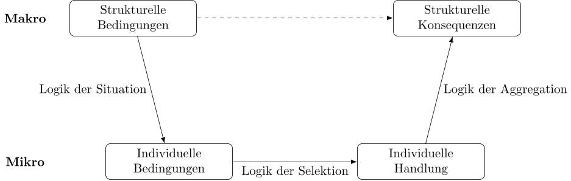

Abbildung 1: Das Makro-Mikro-Makro-Modell

Ergänzend dazu existiert die **Mesoebene** — eine Zwischenebene zwischen Mikro- und Makroebene —, auf der soziale Gebilde wie Organisationen, Institutionen oder Netzwerke betrachtet werden. Diese Strukturen besitzen eigene Regeln und Dynamiken, die sowohl das individuelle Handeln beeinflussen als auch Rückwirkungen auf die aggregierten gesellschaftlichen Strukturen haben können.

Zusammengefasst ermöglicht das Makro-Mikro-Makro Modell eine Mehrebenenerklärung soziologischer Tatbestände: Die Makroebene liefert den strukturellen Rahmen, in dem individuelles Handeln stattfindet. Dieses Handeln vieler Individuen beeinflusst, wenn es aggregiert wird, wieder in die strukturellen Rahmenbedingungen zukünftiger Handlungen — eine kontinuierliche Rückkopplung, die zentrale Dynamiken in Gesellschaften abbildet. Dieses Modell liefert den Rahmen in dem sich viele konkrete Theorien der Sozialstrukturanalyse bewegen.

### 2.4 Theorien mittlerer Reichweite

Nachdem wir uns im vorherigen Abschnitt mit dem Modell soziologischer Erklärungen beschäftigt haben, richten wir nun unseren Blick auf die theoretische Fundierung der Sozialstrukturanalyse. Insbesondere ordnen wir Theorien danach ein, inwieweit sie abstrahieren und empirisch überprüfbar sind. Diese beiden Kriterien — Abstraktionsgrad und empirische Prüfbarkeit — stehen in einem Spannungsverhältnis: Je höher der Abstraktionsgrad, desto allgemeiner und weitreichender ist die Theorie, jedoch nimmt in der Regel ihre direkte empirische Prüfbarkeit ab.

**Einführendes Beispiel:** Stellen Sie sich vor, Sie möchten erklären, warum in bestimmten Gesellschaften soziale Ungleichheiten entstehen. Eine Theorie, die sich unmittelbar mit der Entstehung von Ungleichheit befasst, müsste viele Faktoren wie Bildung, Einkommen, kulturelle Normen und institutionelle Rahmenbedingungen berücksichtigen — ein sehr komplexer Zusammenhang. Theorien mittlerer Reichweite konzentrieren sich dagegen auf einen spezifischen Aspekt, beispielsweise die Rolle von Bildung bei der Reproduktion sozialer Klassen. Solche Theorien sind konkret genug, um daraus empirisch überprüfbare Hypothesen abzuleiten, und gleichzeitig abstrakt genug, um in verschiedenen gesellschaftlichen Kontexten anwendbar und übertragbar zu sein.

Theorien lassen sich hinsichtlich zweier zentraler Dimensionen voneinander unterscheiden und einordnen (vgl. Atteslander 2000):

- **Abstraktionsgrad:** Dieser beschreibt, wie stark empirische Phänomene verallgemeinert werden.
  - Theorien, die nahe an ihrem Untersuchungsgegenstand sind, sind sehr konkret und liefern präzise Vorhersagen, die jedoch oft nur auf spezifische Kontexte und Phänomene beschränkt sind.
  - Ein hoher Abstraktionsgrad ermöglicht es, viele verschiedene Phänomene einzubeziehen, führt aber auch dazu, dass die Theorie in weiten Teilen von konkreten empirischen Fällen entfernt ist.
- **Empirische Prüfbarkeit:** Dieser Aspekt besagt, inwieweit eine Theorie oder daraus abgeleitete Hypothesen durch Daten überprüfbar sind.
  - Eine Theorie, die nicht empirisch prüfbar ist, kann nicht widerlegt werden und bleibt somit immun gegenüber der Realität.
  - Umgekehrt können empirisch prüfbare Theorien oder daraus abgeleitete Hypothesen durch Daten widerlegt werden.

Diese beiden Dimensionen stehen in einem Spannungsverhältnis: Mit zunehmendem Abstraktionsgrad sinkt oft die unmittelbare empirische Prüfbarkeit.

Schematisch lassen sich vier Arten von Theorien hinsichtlich ihres Abstraktionsgrads und ihrer empirischen Prüfbarkeit unterscheiden:

- **Komplexe Theorien:** Diese versuchen, die Gesellschaft als Ganzes oder große Teile davon zu erklären. Sie besitzen einen sehr hohen Abstraktionsgrad und beziehen sich auf zahlreiche Zusammenhänge, weshalb sie oft schwer empirisch zu überprüfen sind. Beispiele für solche komplexen Theorien sind die Systemtheorie (siehe z.B. Luhmann 1984) oder der Strukturfunktionalismus (siehe z.B. Parsons 1951).
- **Theorien mittlerer Reichweite:** Diese konzentrieren sich auf spezifische Bereiche oder Aspekte der Gesellschaft. Sie weisen einen moderaten Abstraktionsgrad auf und sind so konkret formuliert, dass sich daraus empirisch überprüfbare Hypothesen ableiten lassen. Beispiele hierfür sind die Humankapitaltheorie (siehe z.B. Becker 1964) oder die Theorie der sozialen Herkunftseffekte (siehe z.B. Boudon 1974).
- **Ad-hoc-Theorien:** Für spezifische Probleme oder Situationen entwickelte Theorien, wie etwa zur Erklärung der Kriminalitätsrate in einer bestimmten Nachbarschaft, haben einen niedrigen Abstraktionsgrad und sind meist direkt aus empirischen Daten abgeleitet. Ihre Reichweite und Generalisierbarkeit ist oft begrenzt.
- **Empirische Regelmäßigkeiten:** Diese beschreiben beobachtbare Muster oder Zusammenhänge zwischen Variablen. Sie besitzen einen sehr niedrigen Abstraktionsgrad und sind direkt empirisch prüfbar, liefern jedoch keine tiefergehenden Erklärungen für die Ursachen der Phänomene.

Abbildung 2 veranschaulicht schematisch den Zusammenhang zwischen dem Abstraktionsgrad von Theorien bzw. Aussagen und der Häufigkeit empirischer Studien. Dabei werden empirische Regelmäßigkeiten und Ad-hoc-Theorien überwiegend in der *Bedarfsforschung* untersucht — einem Ansatz, der sich auf praktische Probleme und konkrete Anwendungen konzentriert. Hierzu zählt zum Beispiel auch die *Sozialberichterstattung* im Rahmen des [Armuts- und Reichtumsberichts der Bundesregierung](https://www.armuts-und-reichtumsbericht.de), welcher als Ausgangspunkt politischer Planungsprozesse dient oder die *Evaluationsforschung*, welche beispielsweise die Umsetzung und Wirksamkeit politischer Maßnahmen (z.B. [Einführung des Mindeslohns](https://www.mindestlohn-kommission.de)) untersucht. Im Gegensatz dazu werden Theorien mittlerer Reichweite in der *Grundlagenforschung* eingesetzt, um grundlegende Fragen der sozialen Wirklichkeit zu untersuchen. Komplexe Theorien entziehen sich oft der direkten empirischen Analyse, da sie zu abstrakt sind, um daraus konkrete empirische Forschungsprogramme abzuleiten.

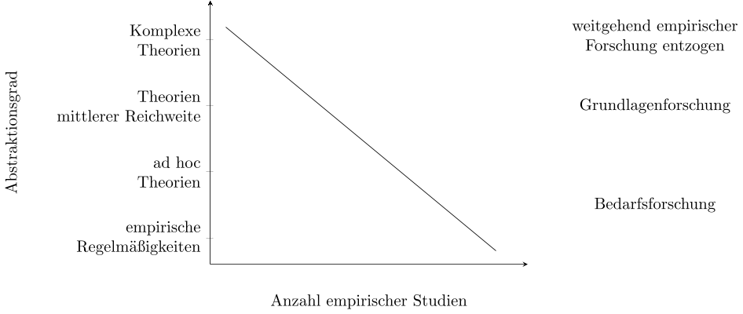

Abbildung 2: Schematische Darstellung des Zusammenhangs zwischen Abstraktionsgrad von Theorien und der Anzahl empirischer Studien (in Anlehnung an Atteslander (2000)).

Für die Sozialstrukturanalyse sind vor allem Theorien mittlerer Reichweite von zentraler Bedeutung, da sie den Spagat zwischen theoretischer Generalisierbarkeit und empirischer Prüfbarkeit meistern. Sie ermöglichen es, konkrete Hypothesen zu formulieren und zu testen, während sie gleichzeitig einen Bezug zu umfassenderen gesellschaftlichen Zusammenhängen bieten. Damit ermöglichen sie es, die Grundidee der Sozialstrukturanalyse zu realisieren: Erklärungen für gesellschaftliche Zustände und Veränderungen zu liefern.

Aus diesem Fokus auf empirisch-prüfbare Theorien mittlerer Reichweite, lässt sich auch direkt das Verhältnis von Theorie und Empirie in der Sozialstrukturanalyse ableiten: Die Sozialstrukturanalyse greift auf wissenschaftliche Theorien zurück, um fundierte Hypothesen über Ursache-Wirkungs-Zusammenhänge aufzustellen und nutzt empirische Daten und Methoden, um diese Hypothesen zu prüfen. Die so entstandenen empirischen Ergebnisse werden wiederum genutzt, um theoretische Annahmen gegebenenfalls zu bestätigen, zu verfeinern, oder zu revidieren.

Grundlegende Informationen zu den Daten und Methoden der Sozialstrukturanalyse sind in den folgenden beiden Kapiteln zu finden.

## 3 Daten

Nachdem wir im vorangegangenen Kapitel die theoretischen Grundlagen der Sozialstrukturanalyse sowie die zentrale Bedeutung der Empirie beleuchtet haben, widmen wir uns nun einem wichtigen Baustein der empirischen Forschung: den Daten. In der Sozialstrukturanalyse interessieren wir uns für Daten, die uns Informationen über Individuen, Gruppen oder ganze Gesellschaften liefern, um die zugrunde liegenden sozialen Zusammenhänge besser zu verstehen. Diese Daten können in unterschiedlichen Formen vorliegen — etwa als Zahlen aus standardisierten Befragungen oder amtlichen Statistiken, als Textpassagen aus Interviews oder als Feldnotizen von Beobachtungen — und werden für verschiedene Zwecke erhoben, sei es für wissenschaftliche Studien oder amtliche Statistiken. Je nach Art und Zielsetzung weisen sie unterschiedliche Stärken und Schwächen auf.

In Kapitel 3.1 werden die zentralen Unterschiede in der Datenerhebung und Zielsetzung quantitativer und qualitativer Ansätze erläutert. Sie erfahren, welche Fragestellungen sich am besten mit welchem Datentyp beantworten lassen und welche Daten die Sozialstrukturanalyse vornehmlich nutzt. In Kapitel 3.2 werden die unterschiedlichen Methoden der Datenerhebung vorgestellt sowie deren jeweilige Vor- und Nachteile erläutert. Unterschiede zwischen Querschnitt-, Trend- und Paneldaten werden in Kapitel 3.3 beleuchtet sowie Vor- und Nachteile der jeweiligen Datentypen gegenübergestellt. In Kapitel 3.4 klären wir, was unter Primär- und Sekundärdaten zu verstehen ist, und beleuchten die spezifischen Herausforderungen sowie Chancen, die beide Datentypen mit sich bringen. Abschließend werden in Kapitel 3.5 wichtige Datenquellen und Datensätze vorgestellt.

Dieses Kapitel legt somit den empirischen Grundstein für die Sozialstrukturanalyse, indem Sie einen tieferen Einblick bekommen, wie Daten erfasst werden, welche Stärken und Schwächen unterschiedliche Verfahren haben und welche gängigen Datensätze es gibt, auf Basis derer die Sozialstruktur von Gesellschaften analysiert werden kann.

### 3.1 Quantitative und qualitative Daten

**Einführendes Beispiel:** Stellen Sie sich vor, Sie möchten untersuchen, warum sich Eltern für eine bestimmte weiterführende Schule für ihr Kind entscheiden, und planen dazu eine eigene Datenerhebung. Schon zu Beginn des Forschungsprozesses müssen Sie entscheiden, in welcher Form Sie die Daten sammeln wollen. Eine Möglichkeit besteht darin, einen standardisierten Fragebogen zu entwickeln, der zahlreiche geschlossene Fragen enthält — beispielsweise zu den Erwartungen der Eltern, den bisherigen schulischen Leistungen und Schwierigkeiten des Kindes. Die Antworten werden dann anhand einer vorgegebenen Skala (beispielsweise mit 5 oder 7 Auswahlmöglichkeiten) oder als Zahlenwerte (z.B. Schulnoten) erfasst. Alternativ können Sie qualitative Daten erheben, indem Sie in Interviews ausführlich mit Eltern sprechen, diese aufzeichnen und anschließend transkribieren und auswerten. Hierbei orientieren Sie sich möglicherweise an einem Leitfaden, erlauben aber den Befragten, weitgehend selbst Schwerpunkte zu setzen. Die erste Variante entspricht einem **quantitativen Ansatz**, während die zweite dem **qualitativen Ansatz** zuzuordnen ist.

Die Unterscheidung in quantitative und qualitative Forschungsdesigns ist eine der zentralen methodischen Unterscheidungen in den Sozialwissenschaften. Mit den unterschiedliche Herangehensweise sind nämlich nicht nur spezifische Stärken und Schwächen verbunden, sondern auch grundlegende Unterschiede in dem Verständnis darüber, wie soziologische Erkenntnisse gewonnen werden. In der Soziologie werden beide Ansätze genutzt, um Informationen über soziale Phänomene und Zusammenhänge zu sammeln und zu analysieren:

- **Quantitative Daten:** Quantitative Daten liegen meist in Form von numerischen Werten vor. Diese entstammen standardisierten Messungen und ermöglichen eine statistische Analyse. Die Ergebnisse lassen sich in Diagrammen und Tabellen visualisieren. Die Vorteile quantitativer Daten bestehen darin,dass sie verallgemeinerbare Aussagen liefern können (z.B. Durchschnittsverdienst in Deutschland) und dabei tendenziell vergleichbar sind (z.B. zwischen Ländern oder im Zeitverlauf). Gleichzeitig können und sollten quantitative Daten reproduzierbare Ergebnisse liefern sofern die gleiche Datengrundlage und Analyseverfahren gewählt werden. Nachteile quantitativer Daten bestehen in den Sozialwissenschaften wiederum darin, dass die soziale Realität nicht in ihrer gesamten Komplexität mit numerischen Indikatoren abgebildet werden kann, sodass bestimmte Phänomene und Zusammenhänge zu oberflächlich erfasst werden.
- **Qualitative Daten:** Qualitative Daten basieren auf nicht-numerischen Informationen, etwa in Form von Texten, Bildern oder Audioaufnahmen. Sie werden oft durch Interviews, Gruppendiskussionen oder teilnehmende Beobachtungen gewonnen. Die Vorteile qualitativer Daten bestehen darin, dass sie ein tieferes Verständnis von Bedeutungen, Motivationen und sozialen Dynamiken ermöglichen und dabei detaillierte Informationen zum Entstehungskontext berücksichtigen. Eine weitere Stärke qualitativer Daten liegt in ihrem Potenzial zur Generierung neuer Hypothesen. Anderseits sind qualitative Daten weniger geeignet, um Erkenntnisse auf größere Populationen zu verallgemeinern. Auch die Reproduzierbarkeit der gewonnen Ergebnisse trotz gleicher Daten und Auswertungsmethoden ist eingeschränkt.

Für eine allgemeine Einführung in die qualitative Methoden siehe z.B. Schiek (2024) oder für eine Einführung in die quantitativen Methoden siehe z.B. Schnell u. a. (2023). Eine detaillierte Gegenüberstellung des qualitativen und quantitativen Paradigmas findet sich z.B. bei Häder (2019). In manchen Fällen werden qualitative und quantitativen Forschungsmethoden auch miteinander kombiniert. Für eine Einführung in die sogenannten *Mixed Methods* siehe z.B. Kelle (2022).

Grundsätzlich richtet sich die Wahl des Ansatzes immer nach der konkreten Forschungsfrage und den angestrebten Zielen Ihrer Forschung: Möchten Sie verallgemeinerbare Aussagen über größere soziale Gruppen treffen (beispielsweise Unterschiede in der Bildungsaspiration zwischen sozialen Klassen), eignet sich ein quantitatives Design; geht es hingegen dem Beispiel folgend darum, tiefere Einsichten zu bekommen, welche Vorstellungen und welches Verständnis von Bildungsaspirationen überhaupt existieren und welche Typen von Eltern sich unterscheiden lassen, ist ein qualitatives Design die bessere Wahl.

Auch wenn die Wahl des Forschungsdesigns grundsätzlich auf die Forschungsfrage angepasst werden sollte, kommt es in der Forschungspraxis häufig vor, dass Forschende sich entweder auf qualitative oder quantitative Methoden spezialisieren. Dies trifft auch auf die Autoren dieses Lehrbuchs zu. So konzentriert sich das Lehrbuch im Folgenden vor allem auf quantitativen Daten und Methoden. Quantitative Verfahren bieten sich für die Fragestellungen der Sozialstrukturanalyse besonders an, da es darum geht, Aussagen über die gesamte Sozialstruktur zu treffen und diese empirisch zu belegen. Dennoch können qualitative Zugänge wichtige Erkenntnisse über soziale Ungleichheiten liefern, die quantitativen Ansätzen tendenziell eher verschlossen bleiben würden (Behrmann u. a. 2018).

### 3.2 Erhebungsformen

Nach der Entscheidung, ob qualitative oder quantitative Daten zur Beantwortung einer Forschungsfrage erhoben und analysiert werden sollen, schließt sich die Frage an, welche Erhebungsform geeignet ist, um die gewünschten Daten zu generieren. Grundsätzlich kann hier zwischen nicht-responsiven und responsiven Daten unterschieden werden.

**Responsive Daten** werden im Gegensatz zu nicht-responsiven Daten speziell zu Forschungszwecken erhoben. Forschende sind an Informationen interessiert, die Studienteilnehmende bewusst und freiwillig zur Verfügung stellen. Die Befragten werden darüber informiert, dass sie Teil einer Studie sind und werden darüber aufgeklärt, was mit ihren Antworten passiert. Responsive Daten entstehen also mit dem Zweck, Forschung zu betreiben. Im Folgenden werden nun die wichtigsten responsiven Erhebungsformen in den Sozialwissenschaften vorgestellt.

- **Beobachtungsdaten:** Eine zentrale Methode der Datenerhebung in der Sozialforschung ist die systematische Beobachtung sozialer Situationen. Dabei werden soziale Interaktionen und Alltagsrituale — etwa in Familien, bei Meetings in Organisationen oder in öffentlichen Räumen — dokumentiert. Die Beobachtung kann sich dabei auf alle sinnlichen Wahrnehmungen stützen und wird je nach Einbeziehung der Forschende in teilnehmende und nicht-teilnehmende Beobachtung unterteilt. Qualitative Analysen von Beobachtungsdaten liefern oft reichhaltige und detaillierte Einblicke in soziale Dynamiken. In manchen Fällen können aus teilnehmender Beobachtung auch quantitative Daten gewonnen werden — ein bekanntes Beispiel ist die *Marienthalstudie* (Jahoda u. a. 1933). In dieser Studie wurde die Veränderung des österreichischen Dorfes Marienthal im Zuge der Massenarbeitslosigkeit Ende der 1920er Jahre untersucht. Quantitative Daten aus den Beobachtungen waren dann beispielsweise die Messung der Schrittgeschwindigkeit über den Erhebungszeitraum (die Menschen gingen immer langsamer) und die Auswahl an Kleidung und anderen Haushaltsprodukten. Wichtig ist dabei, dass Forschende ihre eigene Rolle und Perspektive reflektieren und transparent machen, um Verzerrungen zu vermeiden. Zudem müssen ethische Aspekte wie der Schutz der Privatsphäre und die Einwilligung der Beobachteten beachtet werden.
- **Experimentaldaten:** Experimente gelten als Königsweg der wissenschaftlichen Erkenntnisgewinnung und werden vor allem in den Naturwissenschaften, aber auch in der Psychologie, Verhaltensökonomie und zunehmend auch in der Soziologie eingesetzt. In der Soziologie werden Experimentaldaten durch kontrollierte Versuchsaufbauten gewonnen. Dabei manipulieren Forschende eine oder mehrere unabhängige Variablen (*Treatments*) — erzeugen die Ursache also selbst — und messen die Auswirkungen auf abhängige Variablen. Dies erlaubt es, kausale Zusammenhänge unter kontrollierten Bedingungen zu überprüfen oder aufzudecken. Eine zentrale Rolle spielt dabei die *Randomisierung*, die sicherstellt, dass die Zuordnung der Versuchspersonen zu Kontroll- oder Experimentalgruppen zufällig erfolgt und somit experimentelle Manipulationen unabhängig von spezifischen Merkmalen der Probanden sind. Je nach Setting werden *Laborexperimente*,[^2] *Feldexperimente*[^3] oder *Surveyexperimente* durchgeführt. In der Sozialstrukturanalyse werden vor allem Surveyexperimente — also Experimente, die in Befragungen eingebunden sind — verwendet. Dies hat den Vorteil, dass die Stärke von Experimenten — Nachweis von Ursache-Wirkungs-Zusammenhängen — mit der Stärke von Surveydaten — Verallgemeinerbarkeit der Ergebnisse — kombiniert wird.
- **Surveydaten:** Umfragen — auch *Surveys* genannt —, gehören zu den am häufigsten genutzten Erhebungsmethoden in den Sozialwissenschaften. Mithilfe standardisierter Fragebögen werden Daten zu Meinungen, Einstellungen, Verhaltensweisen und soziodemografischen Merkmalen erhoben. Dabei werden *geschlossene* Fragen mit Antwortvorgaben eingesetzt — z.B. in Form von Ratingskalen in der beispielweise die Zustimmung zu einer Aussage von *(1) Stimme überhaupt nicht zu* bis *(7) stimme voll und ganz zu* erfasst wird. *Offene* Frage hingegen ermöglichen es Befragten ihre Antworten frei zu formulieren. Da Surveydaten vorallem genutzt werden, um quantitative Auswertungen vorzunehmen, werden offene Fragen in der Regel recht sparsam eingesetzt. Surveydaten ermöglichen es, Aussagen über größere Bevölkerungsgruppen zu treffen und Trends sowie Veränderungen im Zeitverlauf zu analysieren (siehe Kapitel 3.3) und deshalb sind sie auch besonders geeignet für die Sozialstrukturanalyse. Neben der Auswahl geeigneter Fragen — diese werden im Survey auch als *Items* bezeichnet — ist die Auswahl der zu befragenden Personen von großer Bedeutung für die Qualität und Aussagekraft der gewonnen Surveydaten. Am Anfang steht die Frage, über wen wir überhaupt Aussagen treffen möchten: Wollen wir etwas über die Allgemeinbevölkerung in Deutschland aussagen? Oder nur über Erwerbstätige? Oder nur über Studierende an der Universität Bielefeld? Die Population über die wir prinzipiell eine Aussage treffen möchten, wird in der Surveyforschung als *Grundgesamtheit* bezeichnet. Während wir uns vielleicht noch vorstellen können, dass wir alle Studierenden der Universität Bielefeld befragen könnten, wird schnell klar, wir könnten auf keinen Fall alle Personen in Deutschland befragen. Das ist aber auch gar nicht notwendig, denn statt einer *Vollerhebung* können wir auch eine zufällige Auswahl der Grundgesamtheit — eine Stichprobe — befragen. Es existieren viele Möglichkeiten, eine solche Stichprobe auszuwählen. Besonders hochwertige Stichproben, die es erlauben, die resultierenden Surveydaten als *repräsentativ* für die Grundgesamtheit zu bezeichnen — beinhalten immer Elemente einer Zufallsauswahl. Stichproben ohne Zufallsauswahl — sogenannte *Convenience Sample* — die vor allem auf Basis eines leichten Zugangs gewählt werden (z.B. Freunde und Familie, die an einer Umfrage für Ihre Abschlussarbeit teilnehmen), lassen in aller Regel keine Aussagen über die Grundgesamtheit zu. *Quoten-Stichproben* nutzen zwar keine echte Zufallsauswahl, versuchen aber zumindest die Zusammensetzung der Grundgesamtheit anhand einiger zentraler soziodemographischer Merkmale (z.B. Alter, Geschlecht, Bildung und Wohnort) widerzuspiegeln.

### 3.3 Querschnitts, Trend- und Paneldaten

Grundsätzlich lassen sich Surveydaten in drei Kategorien einteilen, die sich, erstens, darin unterscheiden, ob eine Befragung einmalig durchgeführt und, zweitens, ob — falls die Befragung wiederholt wird — dieselben oder neue Untersuchungseinheiten befragt werden. Die unterschiedlichen Kategorien von Surveydaten bieten dabei unterschiedliche Vor- und Nachteile, die bei der Auswahl des Forschungsdesigns berücksichtigt werden sollten.

**Querschnittsdaten** erfassen Informationen von verschiedenen Einheiten (Individuen oder anderen Untersuchungseinheiten wie Paare, Haushalte, Betriebe) zu einem bestimmten Zeitpunkt (siehe Abbildung 3). Sie ermöglichen es, den Zustand einer Gesellschaft zu einem bestimmten Zeitpunkt abzubilden und Zusammenhänge zwischen Merkmalen wie Einkommen, Bildung oder Familienstruktur zu analysieren. Im Vergleich zu Wiederholungsbefragungen sind Querschnittsbefragungen häufig thematisch flexibler und kostengünstiger, da die Befragung nur einmal durchgeführt wird. Außerdem müssen wir uns keine Gedanken darüber machen ob und wie, wir dieselben Befragten erneut befragen können. Gleichzeitig liefern Querschnittsdaten nur eine Momentaufnahme und können somit keine Veränderungen über die Zeit abbilden. Das bedeutet auch, Analysen sind auf *Unterschiede zwischen* Individuen oder Gruppen fokussiert. Interessieren wir uns z.B. für den Einfluss der Geburt eines Kindes auf die Erwerbssituation von Frauen, können wir nur jene Frauen, die keine Kinder haben, mit jenen Frauen vergleichen, die Kinder haben. Dieser Vergleich gibt uns jedoch keine Auskunft darüber, wie sich die Erwerbssituation von Frauen durch die Geburt des ersten Kindes verändert.

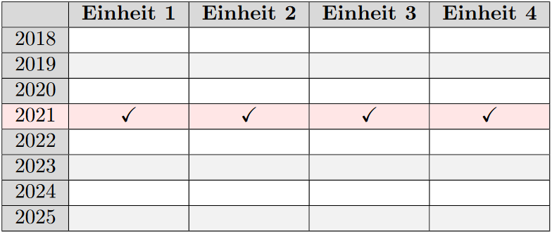

Abbildung 3: Querschnittsdaten

**Trenddaten** werden in regelmäßigen Abständen erhoben, jedoch mit jeweils neuen Stichproben (siehe Abbildung 4). In Grunde genommen, handelt es sich bei Trenddaten also um wiederholte Querschnitte. Wie der Name bereits andeutet, erlauben es Trenddaten, zeitliche Entwicklungen und Trends auf der Makro- oder Gruppeneben zu verfolgen, ohne dass dieselben Personen über die Zeit befragt werden. Im Gegensatz zu einfachen Querschnitten, erlauben Trenddaten sehr wohl die Beobachtung von Veränderungen. Allerdings können die Veränderungen nur auf der Gruppen- und nicht auf der Individualebene beobachtet werden. So könnten Trenddaten z.B. Aussagen darüber ermöglichen, wie sich der Erwerbsumfang von Frauen mit Kinder unter 3 Jahren über die letzten 10 Jahre verändert hat. Um Trends zu analysieren ist es notwendig, dass dieselben Informationen erneut abgefragt werden. Damit sind Befragungen, die darauf abzielen Trends über längere Zeiträume abzubilden, thematische weniger flexible als eine Befragung, die nur einmalig durchgeführt wird. Um dennoch flexible auf neue Themen reagieren zu können, werden häufig Standardfragen, die immer wiederholt werden mit wechselnden Themenmodulen verknüpft.

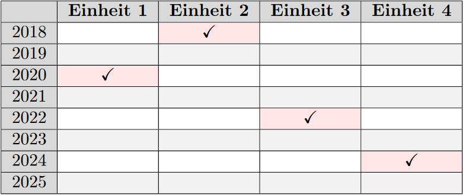

Abbildung 4: Trenddaten

**Paneldaten** sind Längsschnittdaten, bei denen dieselben Untersuchungseinheiten über einen längeren Zeitraum wiederholt befragt werden (siehe Abbildung 5). Anders als bei Querschnitts- und Trenddaten können hier tatsächlich Veränderungen innerhalb von Personen beobachtet werden, sodass Ursache-Wirkungs-Zusammenhänge hergestellt werden. Aus dem obigen Beispiel könnten wir also tatsächlich untersuchen, wie sich die Geburt des ersten Kindes auf den Erwerbsstatus ein und derselben Person auswirkt. Aus diesem Grund bieten Paneldaten besondere analytische Potentiale, die den anderen Datenformen verschlossen bleiben. Gleichzeitig können Paneldaten auch als einzelne Querschnitte oder zur Analyse von Trends herangezogen werden. Teilweise werden Paneldaten daher auch als *,,Goldstandard”* der Surveyforschung bezeichnet. Neben diesen Vorteilen, gehen mit Paneldaten aber auch spezielle Herausforderungen einher. So können Paneldaten nur dann ihr volles Potential ausschöpfen, wenn die ursprünglich ausgewählten Befragten auch wiederholt teilnehmen. In der Forschungspraxis können nicht immer wieder alle Befragten erneut befragt werden: teilweise sind Befragte nicht mehr aufzufinden (z.B. weil sie umgezogen sind) oder wollen nicht erneut teilnehmen. Dieses — auch als *Panelmortalität* — bezeichnete Phänomen sorgt dafür, dass die Stichprobengröße von Panelbefragungen in der Regel über die Zeit schrumpfen würde. Um dem entgegen zu wirken werden *Auffrischungsstichproben* gezogen — d.h. es werden der Stichprobe wieder neue Befragte hinzugefügt. Dies ist auch deshalb notwendig damit die Daten aussagekräftig bleiben, da ja nur Personen in der Stichprobe des Panels wären, die bereits zum Start der Panelbefragung zur Grundgesamtheit gehörten. Das Sozio-ökonomische Panel — kurz *SOEP* — ist 1984 gestartet und ist die deutschlandweit am längsten laufende Panelbefragung. Hätte das SOEP keine Auffrischungsstichproben gezogen, wären in den SOEP-Daten auch heute noch nur Haushalte abgebildet, die bereits 1984 in Westdeutschland gelebt haben. Es wird schnell klar, dass solche Befragungsdaten wohl kaum repräsentativ für Deutschland im Jahr 2025 wären. Ähnlich wie auch bei den Trenddaten, müssen identische Informationen über die Zeit abgefragt werden, um Veränderungen abbilden zu können. Gerade über lange Zeiträume verändern sich jedoch auch die gesellschaftlichen Realitäten (z.B., die Parteienlandschaft, Verbreitung des Internets/Social Media) als auch Forschungsinteressen (z.B. Klimawandel). Hier müssen Panelstudien also die passende Balance zwischen Konstanz und Anpassung finden.

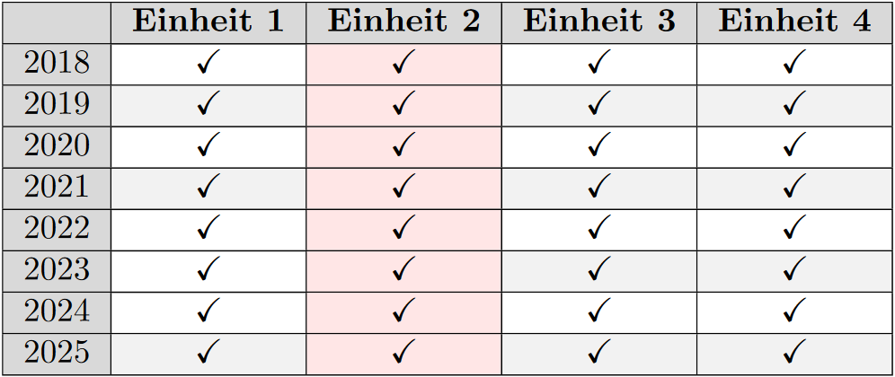

Abbildung 5: Paneldaten

### 3.4 Primär- und Sekundärdaten

**Einführendes Beispiel:** Stellen Sie sich vor, Sie wollen für Ihre Abschlussarbeit, die Auswirkung von Elternschaft auf Karriereverläufe untersuchen. Zuerst überlegen Sie einen qualitativen Zugang zu wählen und über selbst geführte Interviews mit Eltern die subjektive Rekonstruktion von Karriereverläufen nachzuvollziehen. In diesem Fall würden Sie **Primärdaten** erheben. Da Sie sich jedoch weniger für die individuelle Rekonstruktion sondern für verallgemeinerbare Zusammenhänge zwischen Elternschaft und der Entwicklung des beruflichen Status interessieren, entscheiden Sie sich für einen quantitativen Zugang. Zur Beantwortung Ihrer Fragestellung benötigen Sie Informationen zur berufliche Situation und Familienstand von ein und denselben Personen über die Zeit. Eine eigene Erhebung von solchen Paneldaten ist ausgeschlossen und somit greifen Sie auf bereits erhobene Surveydaten zurück. Sie verwenden also **Sekundärdaten**.

**Primärdaten** sind Daten, die im Rahmen eines Forschungsprojekts speziell neu erhoben werden, um die im Projekt gestellten Fragestellungen zu beantworten. Dabei entwickeln Wissenschaftlerinnen und Wissenschaftler oft neue Instrumente — wie speziell konzipierte Fragebögen, Interviews oder Beobachtungsprotokolle —, um relevante Informationen systematisch zu erfassen.

**Sekundärdaten** hingegen sind Daten, die bereits in einem anderen Forschungszusammenhang erhoben wurden, aber dennoch für die Fragestellungen des aktuellen Projekts nutzbar sind. Da die Erhebung von Primärdaten häufig mit erheblichen finanziellen Kosten, personellen Ressourcen und zeitlichem Aufwand verbunden ist, greifen viele Studien auf vorhandene Sekundärdaten zurück. Besonders umfangreiche sozialwissenschaftliche Surveys (vgl. Kapitel 3.5) werden oft als Sekundärdaten genutzt, da diese bereits eine komplexe Datenstruktur aufweisen, die nicht ohne Weiteres selbst aufgebaut werden kann.

Grundsätzlich gilt bei einer empirischen Studie, dass zunächst geschaut wird, ob es geeignete Datensätze gibt, die im Bezug auf die eigene Fragestellung hin untersucht werden können. Die Sekundärdatenanalyse ist forschungsökonomisch sinnvoll und eignet sich auch besonders für Abschlussarbeiten, da man die Risiken der Primärdatenerhebung umgeht.

Die Sekundär- oder Nachnutzung von bereits bestehenden Daten, setzt voraus, dass diese sorgfältig dokumentiert und archiviert werden.

**Dokumentation**: Nur wenn wir wissen, wie genau die vorliegenden Daten entstanden sind, können wir sie sinnvoll weiterverwenden. Deshalb ist es wichtig Vorgehen und Materialien wie zum Beispiel die Auswahl der Stichprobe, Erhebungsmethoden und Fragebögen sorgfältig zu dokumentieren. Eine lückenlose Dokumentation ist jedoch nicht nur für die Sekundärnutzung der Daten in Lehre und weiteren Forschungsprojekten entscheidend, sondern auch notwendig damit die gewonnen Ergebnisse kritisch geprüft und gegebenenfalls reproduziert werden können. Daher ist Dokumentation der Erherbungs- und Auswertungsmethoden eine zentrale Anforderung an die gute wissenschaftliche Praxis.

**Archivierung:** Die Archivierung hingegen stellt sicher, dass die Forschungsdaten weiterhin zugänglich sind. Hierfür existieren verschiedene Modelle, die unterschiedliche Zugriffs- und Nutzungsrechte für Dritte vorsehen. Die maßgebliche Vorgabe ist die Wahrung des Datenschutzes. Enthalten die Daten personenbezogene Daten — also Informationen, die auf eine bestimmte Person zurückgeführt werden können — sind besondere Auflagen für den Datenzugang zu erfüllen. Alternativ können Informationen so vergröbert werden (z.B. wird statt des genauen Einkommens eine Einkommenskategorie angegeben) oder sind so allgemein, dass Sie keine Rückschlüsse auf einzelne Personen zu lassen. Wenn Sie zum Beispiel wissen, dass eine Befragte 25 Jahre ist und eine Ausbildung abgeschlossen hat, dann trifft das auf Tausende Menschen in Deutschland zu und lässt keinen Rückschluss auf einzelne Personen zu. Je seltener ein Merkmal (z.B., Familien mit mehr als 5 Kindern oder Befragte, die über 100 Jahre alt sind), desto höher das Reidentifikationsrisiko. Beispielsweise sind *Campusfiles (CF)* speziell für die Lehre zusammengestellte Datensätze, die meist nur eine Teilstichprobe der ursprünglichen Befragten enthalten und oft weniger sowie vergröberte Informationen aufweisen. Das Analysepotential ist damit eingeschränkt, aber der Zugang erfolgt meist ohne spezielle Datenschutzauflagen. *Public Use Files (PUF)* sind ebenfalls Datensätze, die grundsätzlich ohne weitere Einschränkungen von jedem genutzt werden können, jedoch ebenfalls häufig vergröberte Informationen und weniger Variablen als die Originaldaten enthalten. *Scientific Use Files (SUF)* hingegen werden der wissenschaftlichen Öffentlichkeit zur Sekundärnutzung bereitgestellt. Sie enthalten meist einen größeren Umfang der Originalvariablen und -kategorien, sind jedoch oft nur nach Registrierung oder Abschluss eines Datennutzungsvertrags und unter bestimmten Nutzungsbedingungen zugänglich. Besonders sensible Daten sind teilweise auch nur vor Ort in Forschungsdatenzentren unter besonders strengen technischen und organisatorischen Schutzmaßnahmen nutzbar *(On-site Nutzung)*.

Auch wenn ja nach Art der Daten unterschiedliche Anforderungen an die Dokumentation und Archivierung bestehen können, haben sich die [FAIR-Prinzipien](https://forschungsdaten.info/themen/veroeffentlichen-und-archivieren/faire-daten/) für die Dokumentation, Archivierung und Bereitstellung von Forschungsdaten als allgemeine Leitlinien etabliert.

### 3.5 Ausgewählte Datensätze der Sozialstrukturanalyse

In der empirischen Sozialforschung liefern verschiedene Datensätze die Grundlage, um gesellschaftliche Strukturen und Dynamiken zu untersuchen. Im Folgenden stellen wir einige zentrale Datensätze für Individualdaten vor, die in der Sozialstrukturanalyse häufig Verwendungen finden.

Tabelle 1 stellt Informationen für Datensätze aus Deutschland zusammen und geht insbesondere auch auf die Verfügbarkeit der Daten ein. Die Auswahl der Datensätze setzt einen Fokus auf Allgemeine Bevölkerungsfragen, die ein breites Themenspektrum oder insbesondere Themen der Sozialstrukturanalyse abdecken. Gleichzeitig existiert aber auch eine große Anzahl an themenspezifischen Sekundärdaten. Ein guter Ausgangspunkt für die Suche nach geeigneten Datensätzen ist das Datenarchiv der [GESIS](https://www.gesis.org/angebot/daten-finden-und-abrufen).

Tabelle 1: Ausgwählte Datensätze der Sozialstrukturanalyse für Deutschland

[output not shown]

Wie bereits in Kapitel 2.2 dargestellt, nehmen internationale Vergleiche eine wichtige Funktion in der Sozialstrukturanalyse ein, um die Bedeutung gesellschaftlicher Rahmenbedingungen zu untersuchen. In Tabelle 2 werden zentrale international-vergleichende Datensätze vorstellt.

Tabelle 2: Ausgewählte international-vergleichende Datensätze der Sozialstrukturanalyse

[output not shown]

### 3.6 Ausgewählte Datenbanken für die Sozialstrukturanalyse

Neben Individualdaten — also Daten, die Informationen über einzelne Personen oder Untersuchungseinheiten wie Haushalte, Paare oder Betriebe beinhalten — greift die Sozialstrukturanalyse auch auf aggregierte Daten zurück. Aggregierte Daten bieten Informationen auf der Ebene von Gruppen oder sogar ganzen Ländern. Diese sind wichtig für die Beschreibung der Sozialstruktur einer Gesellschaft — und erfüllen damit eine der zentralen Aufgaben der Sozialstrukturanalyse (siehe Kapitel 1). Solche Indikatoren zur Sozialstruktur können aber auch mit Individualdaten verknüpft werden, um die Verbindung zwischen Makro- und Mikroebene zu untersuchen (siehe Kapitel 2.3). Dies geschieht insbesondere im Rahmen von international-vergleichender Forschung.

**Deutsche Datenbanken:**

- [GENESIS-Online](https://www-genesis.destatis.de/datenbank/online) ist die Datenbank des Bundesamtes für Statistik und stellt aggregierte Informationen aus der amtlichen Statistik zur Verfügung. Datengrundlage sind z.B. der Zensus und Mikrozensus oder das Ausländerzentralregister. Die Statistischen Landesämter stellen ebenfalls umfangreiche Indikatoren zur Verfügung (für NRW siehe z.B. [Statistik.NRW](https://statistik.nrw/)).
- Die [Bundesagentur für Arbeit](https://statistik.arbeitsagentur.de/) stellt umfangreiche Indikatoren rund um das Thema Arbeitsmarkt zur Verfügung. Diese Informationen sind häufig auch auf Ebene bestimmter Berufe oder auf regionaler Ebene oder getrennt nach Geschlecht oder Bildungsniveau verfügbar, sodass sie bereits wichtige Einblicke in zentrale Zusammenhänge der Sozialstrukturanalyse liefern ohne Individualdaten zur Verfügung zu stellen.
- In der Datenbank [INKAR](https://www.inkar.de/) — Indikatoren und Karten zur Raum- und Stadtentwicklung — des Bundesinstituts für Raum-, Stadt- und Raumforschung werden regionalstatistische Indikatoren zu einer breiten Themenauswahl — u.a. Arbeitsmarkt, Wohnen, Bevölkerung, Verkehr — frei zugänglich zur Verfügung gestellt. Die Informationen können heruntergeladen werden oder direkt online Karten zur Visualisierung der Ergebnisse erstellt werden.

**Internationale Datenbanken:**

- [Eurostat](https://ec.europa.eu/eurostat/web/main/data/database) ist die Datenbank des Statistikamtes der Europäischen Union und stellt umfangreiche Indikatoren für EU-Länder (und teilweise auch für Nicht-EU Länder) zur Verfügung. Die Daten können online in einem interaktiven Data Browser abgerufen oder als Datensätze heruntergeladen werden. Ein Vorteil der Eurostat Datenbank ist, dass Indikatoren auf gemeinsamen, EU-weiten Standards beruhen sodass die Vergleichbarkeit zwischen den Ländern in der Regel besonders hoch ist.
- Zwischenstaatliche Organisationen wie die [OECD](https://www.oecd.org/en/data.html) — Organisation für wirtschaftliche Zusammenarbeit und Entwicklung — oder die [Vereinten Nationen](https://data.un.org/) stellen ebenfalls Indikatoren im Länder- und Zeitvergleich zur Verfügung. Die Datenbank der UN bietet eine besonders breite geographische Abdeckung und stellt u.a. Informationen zu den UN Nachhaltigkeitszielen oder von UN Sonderorganisationen — wie z.B. der Weltgesundheitsorganisation (WHO) oder der Internationalen Arbeitsorganisation (ILO) — zusammen.
- [Our World in Data](https://ourworldindata.org/) wird von einer gemeinnützigen Organisation in Kooperation mit der Oxford University betrieben und bietet neben der reinen Bereitstellung von Indikatoren auch interaktive Datenvisualisierungen sowie kurze Berichte und Erläuterung zur Entwicklung zentraler Indikatoren.
- Neben thematisch eher offenen Datenbanken gibt es aber auch thematisch spezialisierte Datenbanken. Für das Themengebiet *Ungleichheit* bieten zum z.B. die Datenbanken der Luxembourg Income Study ([LIS](https://www.lisdatacenter.org/)) oder die World Inequality Database ([WID](https://wid.world/)) Zugang zu umfangreichen Indikatoren im Länder- und Zeitvergleich.

Die vorgestellten Datenbanken sind ohne vorherige Registrierung nutzbar. Wie auch für Indvidualdaten, gilt für aggregierte Informationen, dass Erhebungsmethoden, Datenquellen und Aufbereitungsschritte umfangreich dokumentiert werden müssen. Diese *Meta-Daten* werden in den gelisteten Datenbanken ebenfalls bereitgestellt.

Dieses Kapitel hat einen umfassenden Überblick zu wichtige Datenquellen und Datenformen in der Sozialstrukturanalyse geboten. Wir haben die Unterschiede zwischen Querschnitts-, Trend- und Paneldaten erläutert und die Bedeutung von Sekundärdaten — sowohl von Invidualdaten als auch aggregierten Strukturindikatoren — herausgestellt. Jede dieser Datenarten bringt spezifische Vor- und Nachteile mit sich, die je nach Forschungsfrage und Zielsetzung sorgfältig abgewogen werden müssen. Durch das Verständnis der verschiedenen Datenquellen und deren Erhebungsmethoden sind Sie bestens gerüstet, um in den folgenden Kapiteln empirische Befunde kritisch zu interpretieren und eigene Forschungsprojekte zu entwickeln.

## 4 Methoden

Nachdem wir in Kapitel 2 die theoretische Grundlagen und in Kapitel 3 die verschiedenen Datenarten und wichtige Datensätze vorgestellt wurden, widmen wir uns nun den quantitativen Auswertungsmethoden und erläutert dabei zwei wesentliche Prozesse: das Datenmanagement und die Datenanalyse.

**Exkurs: Primärdatenerhebung**

Zu den Methoden der Sozialstrukturanalyse gehören natürlich auch solche, die mit der Datenerhebung selbst zu tun haben, falls man selbst Primärdaten erhebt. Auch hier gibt es methodische Standards, die die Auswahl und Konstruktion von Fragen sowie die Umsetzung betreffen. Grundsätzlich gilt bei der Primärdatenerhebung, dass man das Rad nicht neu erfinden soll, sondern auf validierte Befragungsinstrumente zurückgreift, sofern diese verfügbar sind. So gibt es beispielsweise demografische Standards, die vorgeben, wie soziodemografische Merkmale wie Geschlecht, Alter, Staatsangehörigkeit, Erwerbsstatus und Familienstand abzufragen sind. Wenn kein inhaltlich sinnvoller Grund besteht, von diesen Standards abzuweichen, sollte man sich an diese halten. Ausführliche Informationen und formulierte Fragen finden sich beispielsweise beim [Statistischen Bundesamt](https://www.destatis.de/DE/Methoden/Demografische-Regionale-Standards/Downloads/demografische-standards-2024.pdf?__blob=publicationFile&v=4).

Darüber hinaus existieren weitere validierte Skalen zu unterschiedlichen inhaltlichen Konstrukten. Eine Auswahl solcher Skalen auf Deutsch sind zum Beispiel im [ZIS](https://zis.gesis.org/) – dem Open Access Repositorium für Messinstrumente der GESIS – verfügbar. Hier finden sich viele Skalen zu Themen wie Arbeit und Arbeitsbelastung, Einstellungen und weiteren relevanten Aspekten. Von den getesteten Skalen weicht man nur dann ab, wenn sie für die eigene Forschung nicht hilfreich erscheinen. In diesem Fall konstruiert man eigene Fragen, testet diese in Pretests anhand definierter Kriterien und setzt sie anschließend in der Befragung ein (siehe z.B. Baur und Blasius 2022).

### 4.1 Datenmanagement

Da für Haus- und Abschlussarbeiten vor allem die Analyse von Sekundärdaten in Frage kommt, gehen wir davon aus, dass unsere Daten bereits erhoben wurden und als Datensatz vorliegen. Wir starten direkt mit dem ersten Vorbereitungsschritt der Auswertung: dem Datenmanagament. Das Datenmanagement umfasst alle Schritte, die notwendig sind, um die vorliegenden Daten in ein Format zu bringen, das für die Analyse geeignet ist. Diese Phase ist entscheidend für die Qualität und Nachvollziehbarkeit der Forschungsergebnisse. Dieselben Analyse und Auswertungsmethoden können natürlich auch für Primärdaten genutzt werden — allerdings sind bei Primärdaten in der Regel eine Reihe von weiteren Vorbereitungsschritten notwendig, die für Sekundärdaten bereits durch den Datenproduzenten erfolgt sind. Zu den zentralen Komponenten des Datenmanagements gehören:

- **Bildung von neuen Variablen:** Häufig müssen aus den bestehenden Informationen im Datensatz neue Variablen gebildet werden. Beispielsweise könnte es in einem Datensatz Informationen zum Geburtsjahr der befragten Personen geben. Anhand des Geburtsjahres und dem Jahr, in dem die Daten erhoben wurden, kann dann die Variable ,,Alter (in Jahren)” gebildet werden.
- **Rekodierung von bestehenden Variablen:** In vielen Fällen werden die Variablen, die in einem Datensatz vorhanden sind in leicht anderer Form benötigt. Die Variablen in die entsprechende Form zu bringen, nennt sich Rekodierung. Beispielsweise könnte eine Bildungsvariable vorliegen, die die Schulabschlüsse sehr fein ausdifferenziert misst. Für Ihre Analyse benötigen Sie aber möglicherweise nur drei Kategorien (Hauptschule, Realschule, Gymnasium). In diesem Fall würden Sie die Informationen vergröbern. In einem anderen Fall ist Antwort nach der Teilnahme an einer Schulform mit 1 = ja und 2 = nein kodiert, sie möchten die Variable aber zur leichteren Interpretation als *Dummy* — so nennt man Variablen, die nur die Ausprägungen 0 und 1 aufweisen — in Ihr Analysemodell aufnehmen. Oder Sie wollen eine Antwortskala so umkodieren, dass z.B. auf einer Zustimmungsskala höhere Werte auch für eine höhere Zustimmung stehen, um Missverständnisse bei der Interpretation zu vermeiden. Auch das gehört zu den Aufgaben des Rekodierens.
- **Datenbereinigung:** Dieser Schritt umfasst die Überprüfung und Korrektur von Fehlern, Inkonsistenzen oder fehlenden Werten in den Daten. Eine sorgfältige Bereinigung ist essenziell, um Fehler in der Analyse und der Interpretation der Ergebnisse zu vermeiden. Sekundärdatensätze sind bereits von den Datenproduzenten aufbereitet — allerdings stellt jede Analyse andere Anforderungen an die Datenaufbereitung sodass die Datenbereinigung auch bei Sekundärdaten wichtig bleibt. Dazu gehört es auch, dass Sie sich jede einzelne Variable, die Sie für Ihre Analyse nutzen möchten genau anschauen. Zum Beispiel kommt es vor, dass Befragte ihr eigenes Einkommen mit 0 Euro angeben, aber gleichzeitig angeben 60 Stunden pro Woche zu arbeiten. Mit hoher Wahrscheinlichkeit liegt hier ein Fehler vor, der Ihre Ergebnisse beeinflussen könnte und Sie sollten diese fehlerhafte Information nicht berücksichtigen. In vielen Datensätzen sind fehlende Werte — auch *Missings* genannt — nach bestimmten Konventionen, die sich von Datensatz zu Datensatz unterscheiden, klassifiziert. Antwortet ein Befragter nicht auf eine Frage, wird z.B. häufig der Wert -99 im Datensatz hinterlegt. Als Teil der Datenaufbereitung müssen Sie dem von Ihnen verwendeten Statistikprogamm (siehe Kapitel 5) jedoch sagen, dass dies für einen fehlenden Wert steht, ansonsten verwendet das Programm einfach den numerischen Wert.
- **Datenintegration:** In einigen Fällen werden Daten aus unterschiedlichen Quellen zusammengeführt. Dabei müssen unterschiedliche Formate, Variablennamen oder Messskalen harmonisiert werden, um eine konsistente Datenbasis zu schaffen. Dies ist z.B. bei *Trenddaten* (siehe Kapitel 3.3) der Fall. Auch das Anspielen von Strukturindikatoren (siehe Kapitel 3.6) erfordert die Integration von verschiedenen Datenquellen. Dazu gehört auch, dass Strukturindikatoren richtig zugeordnet werden — z.B. in dem in einem international-vergleichenden Datensatz länderspezifische Informationen korrekt zu den Befragten aus den jeweiligen Ländern zugeordnet werden.
- **Reduktion des Datensatzes (optional):** Gerade bei Sekundärdaten werden Sie in aller Regel viel mehr Informationen im Datensatz haben, als Sie für Ihre Analyse benötigen. So kann es bei der Übersichtlichkeit — gerade für komplexe Datenstrukturen — helfen, Ihren Analysedatensatz auf die von Ihnen verwendeten Variablen einzugrenzen.

Für das Datenmanagement sollten darüber hinaus zwei wichtige Grundregeln beachtet werden:

- **Sicherung:** Überspeichern Sie nie den Originaldatensatz sondern speichern Sie für Ihr Analyseprojekt einen eigenen Datensatz ab. Grundsätzlich empfiehlt es sich, Veränderungen an Variablen (siehe *Rekodierung*) immer als *neue* Variable abzuspeichern. Im Abgleich zwischen ,,alter’’ und ,,neuer’’ Variable, sollten Sie dann auch immer überprüfen, ob Sie ggf. einen Fehler gemacht haben.
- **Dokumentation:** Alle Schritte des Datenmanagements sollten ausführlich dokumentiert werden. Diese Dokumentation ist notwendig, um die Reproduzierbarkeit der Analyse zu gewährleisten. Dies bedeutet, dass Ziel einer guten Dokumentation ist es, dass jede Person, die über die zugrundeliegenden Daten verfügt, ihre Ergebnisse 1:1 reproduzieren kann. Um die einzelnen Schritte nachvollziehen zu können, ist es sinnvoll, die einzelnen Datenaufbereitungs- und später auch Analyseschritte kurz zu beschreiben.

### 4.2 Datenanalyse

Nachdem die Daten aufbereitet wurden, folgt die eigentliche Datenanalyse. Diese gliedert sich in zwei Hauptbereiche: die deskriptive Statistik, um sozialwissenschaftliche Zusammenhänge zu beschreiben und die schließende Statistik, um sozialwissenschaftliche Erklärungen empirisch zu testen. Wir beschränken unsere kurze Einführung in die deskriptiven und schließenden Statistik ausschließliche auf Maße, die im weiteren Verlauf des Lehrbuchs Verwendung finden.

#### 4.2.1 Deskriptive Statistik

Die deskriptive Statistik fasst die Daten zusammen und stellt zentrale Merkmale in komprimierter Form dar. Zu den wesentlichen Verfahren zählen:

- **Lagemaße:** Diese Maße geben einen Überblick über die zentrale Tendenz der Daten. Zu den wichtigsten Lagemaßen zählen das arithmetische Mittel, der Median und Modalwerte.

  Das *arithmetische Mittel* wird berechnet als:
  $$\bar{x} = \frac{1}{n} \sum_{i=1}^{n} x_i,$$

  wobei ($x_i$) die einzelnen Datenwerte und ($n$) die Anzahl der Beobachtungen sind.

  Der *Median* teilt einer sortierte Dartenreihe in zwei gleich große Hälften. Für eine ungerade Anzahl $n$ gilt:
  $$Median = x_{\frac{n+1}{2}}$$

  Und für einge gerade Anzahl $n$ wird der Median als Durchschnitt der mittleren beiden Werte berechnet:
  $$Median = \frac{x_{\frac{n}{2}} + x_{\frac{n}{2}+1}}{2}$$
- **Anteile**: Anteile oder Proportionen, geben den relativen Anteil von Beobachtungen in einer bestimmten Kategorie an. Sie werden meist als Prozentsatz ausgedrückt und wie folgt berechnet:

  $$p = \frac{n_{Kategorie}}{n} \times 100\% ,$$

  wobei $n_{Kategorie}$ die Anzahl der Beobachtungen in der betreffenden Kategorie und $n$ die Gesamtzahl der Beobachtungen darstellt.
- **Streuungsmaße**: Diese Maße beschreiben. wie stark die Daten um die zentrale Tenden streuen. Wichtige Streuungsmaße sind:
  - Standardabweichung und Varianz,
  - Quartile und Dezile,
  - der Ginikoeffizient, der häufig zur Messung von Ungleichheiten verwendet wird. Er wird beispielhaft berechnet als:
    $$G = \frac{\sum_{i=1}^{n} \sum_{j=1}^{n} \left| x_i - x_j \right|}{2n^2 \bar{x}},$$

    wobei $\bar{x}$ das arithmetische Mittel der Daten darstellt.

Die univariate[^4], deskriptive Statistik liefert somit wichtige Ausgangsinformationen, die als Basis für weiterführende Analysen dienen.

Wenn man in einem weiteren Schritt den Zusammenhang zwischen zwei Merkmalen untersuchen möchte — diese Analysen werden auch als *bivariat* bezeichnet — , wählt man je nach Skalenniveau der Variablen unterschiedliche Maße. Im Folgenden stellen wir die gängigen Maße vor:

- **Nominale Variablen:** Bei nominalen Daten wird häufig der *Chi-Quadrat-Test* verwendet, um die Unabhängigkeit der Variablen zu überprüfen. Zur quantitativen Messung des Zusammenhangs eignet sich zudem *Cramérs V*, dessen Formel lautet:
  $$V = \sqrt{\frac{\chi^2}{n (k-1)}},$$
  wobei $\chi^2$ der Chi-Quadrat-Wert, $n$ die Gesamtzahl der Beobachtungen und $k$ die kleinere der beiden Kategorienzahlen (Zeilen oder Spalten) ist.
- **Ordinale Variablen:** Für ordinalskalierte Daten bietet sich der *Spearman-Rangkorrelationskoeffizient* an, der den Zusammenhang zwischen den Rängen der Werte misst. Eine vereinfachte Formel lautet:

  $$r_s = 1 - \frac{6 \sum d_i^2}{n(n^2-1)},$$
  wobei $d_i$ die Differenz zwischen den Rangplätzen der einzelnen Beobachtungen und $n$ die Anzahl der Beobachtungen darstellt.
- **Intervall- und Verhältnisskalierte Variablen:** Für diese Datenarten wird häufig der *Pearson-Korrelationskoeffizient* verwendet, der den linearen Zusammenhang zwischen zwei Variablen misst. Die Formel lautet:
  $$r = \frac{\sum (x_i - \bar{x})(y_i - \bar{y})}{\sqrt{\sum (x_i - \bar{x})^2 \sum (y_i - \bar{y})^2}},$$
  wobei $x_i$ und $y_i$ die einzelnen Werte der beiden Variablen, $\bar{x}$ und $\bar{y}$ deren Mittelwerte und $n$ die Anzahl der Beobachtungen sind.

#### 4.2.2 Schließende Statistik

Die schließende oder auch inferenzstatistische Analyse geht über die reine Beschreibung der Daten hinaus und zielt darauf ab, Erkenntnisse über Ursache-Wirkungs-Zusammenhänge zu bekommen. Es gibt es zahlreiche Lehrbücher, die sich mit den epistemologisch und statistischen Grundlagen der Identifikation von solchen kausalen Zusammenhängen beschäftigen (siehe z.B. Cunningham 2021; Huntington-Klein 2013; Pearl und Mackenzie 2018; Wooldrige 2013). Für diese Einführung in die angewandte Sozialstrukturanalyse greifen wir lediglich auf ein einzelnes, aber dafür grundlegendes Verfahren zurück: die lineare Regressionsanalyse, die den Einfluss von unabhängigen Variablen auf eine abhängige Variable quantifiziert. Im Gegensatz zur bivariaten Statistik werden also bei diesem Verfahren mehrere unabhängige Variablen gleichzeitig in ihrer Wirkungsweise auf die abhängige Variable untersucht.

Angenommen, Sie möchten untersuchen, wie das Einkommen (abhängige Variable) durch Faktoren wie Bildungsniveau, Berufserfahrung und Geschlecht (unabhängige Variablen) beeinflusst wird. Mithilfe der Regressionsanalyse können Sie feststellen, in welchem Maße jede dieser Variablen zum Gesamteinkommen beiträgt. Zusätzlich können Sie Kontrollvariablen einbeziehen, um den Einfluss anderer, potenziell störender Faktoren zu berücksichtigen.

- **Abhängige Variable:** Die Variable, deren Variation erklärt oder vorhergesagt werden soll (z.B. Einkommen).
- **Unabhängige Variablen:** Die Variablen, von denen angenommen wird, dass sie einen Einfluss auf die abhängige Variable ausüben (z.B. Bildungsniveau, Berufserfahrung, Geschlecht) und zu deren Wirkungsweise und Richtung Hypothesen formuliert wurden.
- **Kontrollvariablen:** Variablen, die in die Analyse einbezogen werden, um den Effekt störender Einflussfaktoren (Drittvariablen) zu minimieren und den spezifischen Einfluss der interessierenden unabhängigen Variablen besser zu isolieren.

**Das Regressionsmodell:** Das einfachste Modell ist die lineare Regression, die sich folgendermaßen formulieren lässt:
$$y_i = \beta_0 + \beta_1 x_{1,i} + \beta_2 x_{2,i} + \cdots + \beta_k x_{k,i} + \varepsilon_i,$$
wobei: $y_i$ der Wert der abhängigen Variable für die $i$-te Beobachtung ist, $\beta_0$ der Achsenabschnitt (Intercept) darstellt, $\beta_1, \beta_2, \dots, \beta_k$ die Regressionskoeffizienten der unabhängigen Variablen $x_1, x_2, \dots, x_k$ sind, $\varepsilon_i$ der Fehlerterm ist, der die Abweichung der beobachteten Werte von den durch das Modell vorhergesagten Werten beschreibt.

Die Koeffizienten $\beta_j$ geben an, wie stark sich $y$ ändert, wenn sich $x_j$ um eine Einheit verändert — unter der Annahme, dass alle anderen Variablen konstant gehalten werden. Mithilfe statistischer Tests, wie dem t-Test, kann überprüft werden, ob diese Koeffizienten signifikant von null verschieden sind. Ist dies der Fall, weist dies darauf hin, dass die jeweilige unabhängige Variable einen statistisch signifikanten Einfluss auf die abhängige Variable ausübt.

In diesem Kapitel haben wir die methodischen Grundlagen für die quantitative Datenanalyse vorgestellt. Zunächst haben wir das Datenmanagement als notwendigen Schritt der Datenaufbereitung behandelt — von der Variablenkonstruktion über die Datenbereinigung bis hin zur Integration verschiedener Datensätze und Dokumentation des eigenen Vorgehens. Anschließend wurde die Datenanalyse in zwei Hauptbereiche unterteilt: die deskriptive Statistik, die zentrale Merkmale der Daten zusammenfasst, und die inferenzstatistische Analyse, die es ermöglicht, Hypothesen zu testen. Diese Methoden bilden die Grundlage für die empirische Analyse sozialer Strukturen.

## 5 Software

In diesem Buch konzentrieren wir uns auf zwei der am häufigsten eingesetzten Statistikprogramme in den Sozialwissenschaften: **Stata** und **R**. Alle Anwendungsbeispiele, die in den späteren Kapiteln folgen, basieren auf diesen Programmen.

### 5.1 Stata

Stata ist eine leistungsstarke, kommerzielle Statistiksoftware, die in der Soziologie und Ökonomie weit verbreitet ist. Zu den zentralen Merkmalen von Stata gehören:

- **Datenmanagement:** Stata ermöglicht einen schnellen und unkomplizierten Import, die Bereinigung und Rekodierung von Daten.
- **Statistische Analysen:** Stata bietet eine breite Palette von Analyseverfahren — von einfachen deskriptiven Statistiken über lineare und nicht-lineare Regressionen bis hin zu komplexen Panel- und Clusteranalysen. Neben den direkt vom Programm zur Verfügung gestellten Funktionen, können auch von Nutzern genierte Erweiterungen — *ados* — genutzt werden.
- **Programmierung und Reproduzierbarkeit:** Stata unterstützt sowohl die Befehlszeile als auch eine grafische Benutzeroberfläche. Analysen können in sogenannten *Do-files* dokumentiert und automatisiert ausgeführt werden, was die Reproduzierbarkeit der Ergebnisse sicherstellt.
- **Datenvisualisierung:** Mit Stata lassen sich Grafiken und Diagramme erstellen, die die Ergebnisse der Datenanalyse anschaulich präsentieren.

Für eine praktische Einführung in die Datenanalyse mit Stata siehe z.B. Long (2009) oder Kohler und Kreuter (2017).

### 5.2 R

R ist eine Open-Source-Statistiksoftware und wird zunehmend in der Soziolgie und der Ökonomie genutzt. Darüber hiaus arbeiten auch private Unternehmen mit der Software. Zu den Hauptmerkmalen von R zählen:

- **Datenmanagement:** R bietet leistungsstarke Funktionen zur Datenmanipulation und -bereinigung. Mit zahlreichen Paketen können Daten importiert, transformiert und zusammengeführt werden.
- **Statistische Analysen:** R unterstützt eine Vielzahl statistischer Methoden — von einfachen deskriptiven Analysen bis hin zu komplexen Regressions- und multivariaten Modellen. Dank einer umfangreichen Bibliothek an Erweiterungspaketen stehen viele Analysetechniken zur Verfügung, die beständig durch neue Funktionen erweitert werden.
- **Programmierung und Reproduzierbarkeit:** R ermöglicht das Schreiben von Skripten, in denen alle Analyseschritte dokumentiert werden. Dies erhöht die Reproduzierbarkeit, da der gesamte Analyseprozess nachvollziehbar und wiederholbar ist.
- **Datenvisualisierung:** Mit Paketen wie *ggplot2* bietet R sehr gute Möglichkeiten zur Visualisierung von Daten — von einfachen Diagrammen bis zu interaktiven Grafiken.
- **Kostenfreiheit und Community-Support:** R ist kostenlos verfügbar und profitiert von einer aktiven Community, die kontinuierlich neue Pakete, Tutorials und Schulungsmaterialien bereitstellt.

Für eine praktische Einführung in die Datenanalyse mit R siehe z.B. Andrews (2021) oder LLaudet und Imai (2022).

Grundsätzlich gilt bei der Nutzung dieser Programme, dass gerade die ersten Schritte mühsam sind und es eine gewisse Zeit benötigt, bis man einen guten *Workflow* gefunden hat. Gemäß dem Motto ,,programmieren ist googlen”, muss man viele Befehle nachschauen, bis man sie flüssig beherrscht. Auch bei Fehlermeldungen hilft häufig eine Suche im Internet weiter. Auch KI-Modelle können mittlerweile bei der Suche nach und Korrektur von Fehlern helfen. Aber auch hier gilt, dass die KI teils eigene Fehler produziert oder ungewollte Änderungen umsetzt. Deshalb ist es wichtig, selbst ein gutes Grundverständnis für die verwendete Statistiksoftware und Funktionen zu bekommen. Die Anwendungskapitel in Teil 3 dieses Lehrbuchs können dabei als Ausgangspunkt dienen.

## 6 Literatur

Abramowski, Ruth; Heilmar, Till (2025): #moralischverletzt – Berufsethische Ansprüche und die Artikulation kollektiver Ungerechtigkeitserfahrungen von Pflegekräften während der Coronapandemie, in: *Zeitschrift für Soziologie*, Jg. 54, Nr. 1, S. 29–46, doi: 10.1515/zfsoz-2025-2005/.

Alexander, Jeffrey C.; Giesen, Bernhard; Münch, Richard; u. a. (Hrsg.) (1987): *The Micro-Macro Link*, Berkeley: University of California Press.

Andrews, Mark (2021): *Doing Data Science in R: An Introduction for Social Scientists*, Los Angeles: Sage.

Atteslander, Peter (2000): *Methoden der empirischen Sozialforschung*, 9.Aufl. Auflage, Berlin: Walter de Gruyter.

Baur, Nina; Blasius, Jörg (Hrsg.) (2022):, in: *Handbuch Methoden der empirischen Sozialforschung*, Wiesbaden: Springer Fachmedien Wiesbaden, doi: 10.1007/978-3-658-37985-8.

Becker, Gary S. (1964): *Human Capital. A Theoretical and Empirical Analysis with Special Reference to Education*, Chicago/London: University of Chicago Press.

Behrmann, Laura; Eckert, Falk; Gefken, Andreas; u. a. (Hrsg.) (2018): *Doing Inequality*, Wiesbaden: Springer VS, doi: 10.1007/978-3-658-07420-3.

Blumer, Herbert (1969): *Symbolic Interactionism. Perspective and Method*, New Jersey: Englewood Cliffs.

Boudon, Raymond (1974): *Education, opportunity, and social inequality : changing prospects in Western society*, New York: Wiley.

Coleman, James S. (1991): *Grundlagen der Sozialtheorie*, München: Oldenbourg.

Cunningham, Scott (2021): *Causal Inference: The Mixtape*, Boca Raton: CRC Press.

Durkheim, Émile (1897): *Le suicide. Étude de sociologie*, Paris: Félix Alcan.

Ebbinghaus, Bernhard (2005): When less is more: Selection problems in large-N and small-N cross-national comparisons, in: *International sociology*, Jg. 20, Nr. 2, S. 133–152.

Esser, Harmut (1993): *Soziologie. Allgemeine Grundlagen*, Frankfurt am Main/New York: Campus.

Esser, Harmut (2001): *Soziologie. Spezielle Grundlagen*, Frankfurt am Main/New York: Campus.

Habermas, Jürgen (1981): *Theorie des kommunikativen Handelns*, Frankfurt am Main: Suhrkamp.

Häder, Michael (2019): *Empirische Sozialforschung. Eine Einführung*, 4. Aufl., Frankfurt am Main/New York: Springer.

Harkness, Janet A (2012): Comparative survey research: Goals and challenges, in: Edith D. de Leeuw, Joop J. Hox, und Don A. Dillman (Hrsg.), *International Handbook of Survey Methodology*, Routledge, S. 56–77.

Hillmann, Karl-Heinz; Günter Hartfiel (Hrsg.) (1994): *Wörterbuch der Soziologie*, 4., überarb. und erg. Aufl., Stuttgart: Kröner (Kröners Taschenausgabe).

Huinink, Johannes; Brüderl, Josef; Nauck, Bernhard; u. a. (2011): Panel analysis of intimate relationships and family dynamics (pairfam): Conceptual framework and design, in: *Zeitschrift für Familienforschung*, Jg. 23, Nr. 1, S. 77–101.

Hundenborn, Janina; Enderer, Jörg (2019): Die Neuregelung des Mikrozensus ab 2020, in: *WISTA*, Jg. 6, S. 9–17.

Huntington-Klein, Nick (2013): *The Effect*, Mason: South-Western.

Jahoda, Marie; Lazarsfeld, Paul Felix; Zeisel, Hans (1933): *Die Arbeitslosen von Marienthal. Ein soziographischer Versuch über die Wirkungen langandauernder Arbeitslosigkeit*, Leipzig: Hirzel.

Kelle, Udo (2022): Mixed Methods, in: Nina Baur und Jörg Blasius (Hrsg.), *Handbuch Methoden der empirischen Sozialforschung*, Wiesbaden: Springer Fachmedien Wiesbaden, S. 153–166, doi: 10.1007/978-3-658-37985-8_9.

Kohler, Ulrich; Kreuter, Frauke (2017): *Datenanalyse mit Stata*, 5. Aufl., Berlin: Walter de Gruyter.

LLaudet, Elena; Imai, Kosuke (Hrsg.) (2022): *Data Analysis for Social Science: A Friendly and Practical Introduction*, Princeton, New Jersey: Princeton University Press.

Long, J. Scott (2009): *The Workflow of Data Analysis Using Stata*, 5. Aufl., College Station: Stata Press.

Luhmann, Niklas (1984): *Soziale Systeme. Grundriß einer allgemeinen Theorie.*, Frankfurt am Main: Suhrkamp.

Parsons, Talcott (1951): *The Social System*, Alexandria, VA: Free Press.

Pearl, Judea; Mackenzie, Dana (2018): *The Book of Why*, New York: Basic Books.

Schiek, Daniela (2024): *Methoden der qualitativen Sozialforschung*, Bielefeld: transcript.

Schnell, Rainer; Hill, Paul B.; Esser, Elke (2023): *Methoden der empirischen Sozialforschung*, 12. Aufl., Berlin/Boston: DeGruyter Oldenbourg.

Tutić, Andreas (Hrsg.) (2020): *Rational Choice*, Berlin: Walter de Gruyter, doi: 10.1515/9783110673616.

Weber, Max (1920): Die protestantische Ethik und der Geist des Kapitalismus, in: *Gesammelte Aufsätze*, Tübingen.

Wooldrige, Jeffrey M. (2013): *Introductory Econometrics: A Modern Approach*, Mason: South-Western.

## Fußnoten

[^1]: Das Makro-Mikro-Makro-Modell ist nicht auf eine bestimmte Handlungstheorie festgelegt. Besonders häufig werden jedoch Theorien herangezogen, die eine Maximierung des subjektiven Nutzen einer Handlung annehmen. Allerdings können auch andere Handlungstheorien wie beispielsweise der symbolische Interaktionismus (siehe z.B. Blumer 1969) oder die Theorie des kommunikativen Handelns (Habermas 1981) herangezogen werden. Diese unterschiedlichen Ansätze bieten jeweils eigene Perspektiven darauf, wie persönliche Entscheidungen zustande kommen und in sozialen Interaktionen eingebettet sind.
[^2]: Die Bezeichnung erinnert an die naturwissenschaftliche Forschung im Labor, aber der Begriff *Labor* meint hier nur, dass Laborexperimente in eigens dafür vorgesehenen Räumlichkeiten durchgeführt, da so alle anderen Faktoren — die nicht manipuliert werden sollen — für alle Teilnehmenden konstant gehalten werden. Dies hat den Vorteil, dass mögliche Störfaktoren ausgeschlossen werden können, gleichzeitig sorgt es auch dafür, dass der Test das kausalen Zusammenhangs in einer künstlichen Umgebung stattfindet. So stellt sich die Frage, ob sich das im Labor beobachtete Ergebnis auch ,,in der echten Welt” zeigen würde.
[^3]: Feldexperimente werden unter natürlichen Bedingungen — ,,im Feld” — durchgeführt. Dabei wissen Teilnehmende des Experiments häufig gar nicht, dass Sie an einem Experiment teilnehmen. Diese Vorgehen hat den Vorteil, dass ,,echtes Verhalten” beobachtet werden kann, das nicht von der künstlichen Situation des Experiments oder Kenntnis über die Teilnahme an einem Experiment beeinflusst wird. Anderseits haben Forschende viel weniger Kontrolle über die Situation, sodass das unkontrollierte Einflüsse, die Ergebnisse beeinflussen könnten.
[^4]: Univariat bedeutet, dass nur eine Variable, d.h. ein Merkmal, an der Analyse beteiligt ist.